# Mixed-Effect Modeling in R

Martin Schweinberger

2021-04-29

[figure not shown]

# Introduction

This workshop introduces mixed-effects regression modeling using R. The RMarkdown document for the tutorial can be downloaded [here](https://slcladal.github.io/mmws.Rmd) and the bib library [here](https://slcladal.github.io/bibliography.bib). You will find more elaborate explanations and additional examples [here](https://slcladal.github.io/regression.html).

The workshop consists of 2 parts:

1. **Theoretical background and basics**: this part deals with main concepts and the underlying logic of linear and logistic (mixed-effects) regression models
2. **Practical examples and potential issues**: this part focuses on the practical implementation of linear and logistic mixed-models.

### Preparation and session set up

```r
# set options
options(stringsAsFactors = F)         # no automatic data transformation
options("scipen" = 100, "digits" = 10) # suppress math annotation
# install packages
install.packages(c("boot", "car", "caret", "tidyverse",  "effects", "foreign",
                   "Hmisc", "DT", "knitr", "lme4", "MASS", "mlogit", "msm",
                   "QuantPsyc", "reshape2", "rms", "sandwich", "sfsmisc", "sjPlot",
                   "vcd", "visreg", "MuMIn", "lmerTest"))
```

Once you have installed R and RStudio and initiated the session by executing the code shown above, you are good to go.

# Theoretical Background

Regression models are among the most widely used quantitative methods in the language sciences. Regressions are used because they are very flexible and can handle multiple predictors and responses. In general, regression models provide information about if and how predictors (variables or interactions between variables) correlate with a certain response.

The most widely use regression models are

- linear regression (dependent variable is numeric, no outliers)
- logistic regression (dependent variable is binary)
- ordinal regression (dependent variable represents an ordered factor, e.g. Likert items)
- multinomial regression (dependent variable is categorical)

If regression models contain a random effect structure which is used to model nestedness or dependence among data points, the regression models are called *mixed-effect models*. Regressions that do not have a random effect component to model nestedness or dependence are referred to as fixed-effect regressions (we will have a closer look at the difference between fixed and random effects below).

There exists a wealth of literature focusing on regression analysis and the concepts it is based on. For instance, there are Achen (1982), Bortz (2006), Crawley (2005), Faraway (2002), Field, Miles, and Field (2012) (my personal favorite), Gries (2021), Levshina (2015), and Wilcox (2009) to name just a few. Introductions to regression modeling in R are Baayen (2008), Crawley (2012), Gries (2021), or Levshina (2015).

The idea behind regression analysis is expressed formally in the equation below where$f_{(x)}$ is the $y$-value we want to predict, $\alpha$ is the intercept (the point where the regression line crosses the $y$-axis), $\beta$ is the coefficient (the slope of the regression line).

$f_{(x)} = \alpha + \beta_{i}x + \epsilon$

In other words, to estimate how much some weights who is 180cm tall, we would multiply the coefficent (slope of the line) with 180 ($x$) and add the value of the intercept (point where line crosses the $y$-axis). If we plug in the numbers from the regression model below, we get

-93.77 + 0.98 ∗ 180 = 83.33 (kg)

Residuals are the distance between the line and the points (the red lines) and it is also called *variance*. Regression lines are those lines where the sum of the red lines should be minimal. The slope of the regression line is called *coefficient* and the point where the regression line crosses the y-axis is called the *intercept*.

The basic principle

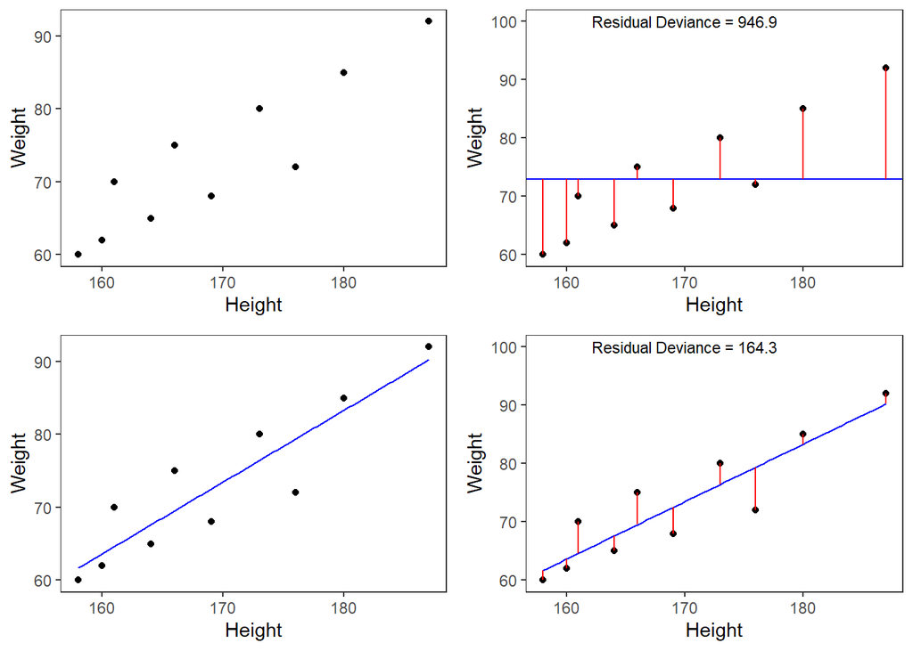

```r
# model for upper panels
summary(glm(Weight ~ 1, data = df))
```

```
##
## Call:
## glm(formula = Weight ~ 1, data = df)
##
## Deviance Residuals:
##    Min      1Q  Median      3Q     Max
## -12.90   -7.15   -1.90    5.85   19.10
##
## Coefficients:
##                Estimate  Std. Error  t value        Pr(>|t|)
## (Intercept) 72.90000000  3.24362623 22.47485 0.0000000032376 ***
## ---
## Signif. codes:  0 '***' 0.001 '**' 0.01 '*' 0.05 '.' 0.1 ' ' 1
##
## (Dispersion parameter for gaussian family taken to be 105.211111111)
##
##     Null deviance: 946.9  on 9  degrees of freedom
## Residual deviance: 946.9  on 9  degrees of freedom
## AIC: 77.88485464
##
## Number of Fisher Scoring iterations: 2
```

```r
# model for lower panels
summary(glm(Weight ~ Height, data = df))
```

```
##
## Call:
## glm(formula = Weight ~ Height, data = df)
##
## Deviance Residuals:
##          Min            1Q        Median            3Q           Max
## -7.393864424  -2.360959921   0.009648689   3.114176150   5.445324097
##
## Coefficients:
##                  Estimate    Std. Error  t value   Pr(>|t|)
## (Intercept) -93.775853538  27.037898638 -3.46831 0.00846372 **
## Height        0.983918852   0.159385448  6.17320 0.00026713 ***
## ---
## Signif. codes:  0 '***' 0.001 '**' 0.01 '*' 0.05 '.' 0.1 ' ' 1
##
## (Dispersion parameter for gaussian family taken to be 20.5363681346)
##
##     Null deviance: 946.9000000  on 9  degrees of freedom
## Residual deviance: 164.2909451  on 8  degrees of freedom
## AIC: 62.36930885
##
## Number of Fisher Scoring iterations: 2
```

Extending the basic principle to logistic regression

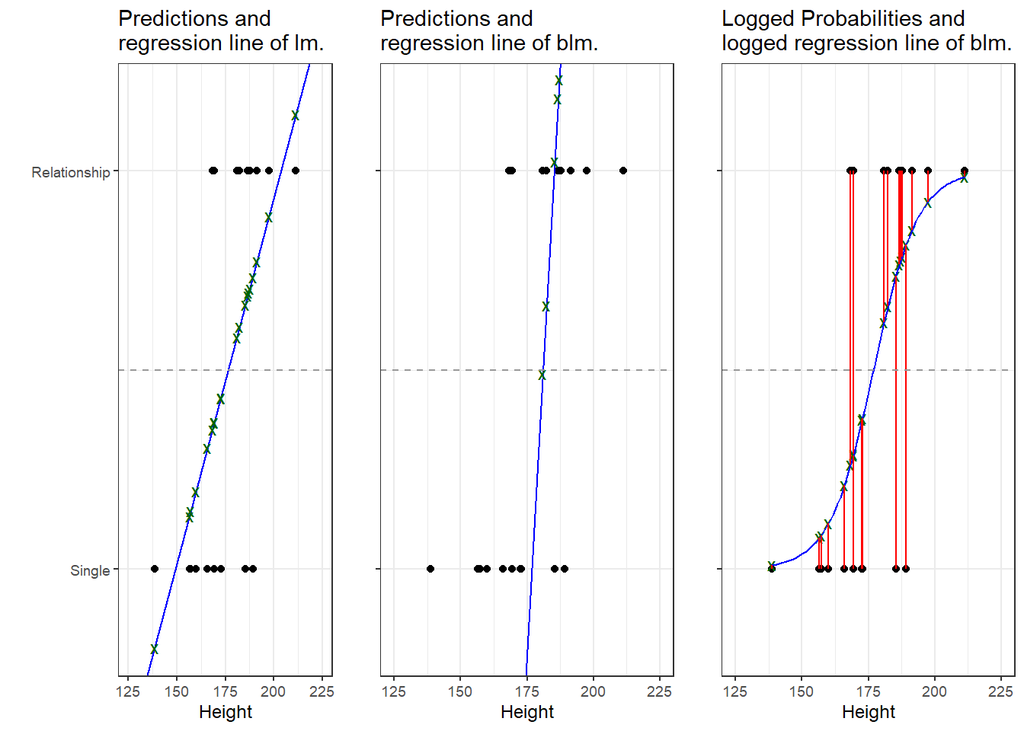

```r
# model for left panel
summary(lm(relationship ~ bodyheight, data = blrdata))
```

```
##
## Call:
## lm(formula = relationship ~ bodyheight, data = blrdata)
##
## Residuals:
##           Min            1Q        Median            3Q           Max
## -0.7334180495 -0.3201542473 -0.0089165163  0.3066564523  0.6504964337
##
## Coefficients:
##                   Estimate     Std. Error  t value Pr(>|t|)
## (Intercept) -2.75502948689  1.02862153467 -2.67837  0.01534 *
## bodyheight   0.01843892419  0.00580233181  3.17785  0.00521 **
## ---
## Signif. codes:  0 '***' 0.001 '**' 0.01 '*' 0.05 '.' 0.1 ' ' 1
##
## Residual standard error: 0.4218342 on 18 degrees of freedom
## Multiple R-squared:  0.359401269,    Adjusted R-squared:  0.32381245
## F-statistic: 10.0987132 on 1 and 18 DF,  p-value: 0.00521000657
```

```r
# model for center and right panel
summary(glm(relationship ~ bodyheight, data = blrdata, family = "binomial"))
```

```
##
## Call:
## glm(formula = relationship ~ bodyheight, family = "binomial",
##     data = blrdata)
##
## Deviance Residuals:
##           Min             1Q         Median             3Q            Max
## -1.8358979635  -0.7196070865   0.0182242587   0.7199585491   1.6351314307
##
## Coefficients:
##                   Estimate     Std. Error  z value Pr(>|z|)
## (Intercept) -21.3479043085   9.5592650578 -2.23322 0.025535 *
## bodyheight    0.1206627924   0.0538103342  2.24237 0.024937 *
## ---
## Signif. codes:  0 '***' 0.001 '**' 0.01 '*' 0.05 '.' 0.1 ' ' 1
##
## (Dispersion parameter for binomial family taken to be 1)
##
##     Null deviance: 27.72588722  on 19  degrees of freedom
## Residual deviance: 18.66566218  on 18  degrees of freedom
## AIC: 22.66566218
##
## Number of Fisher Scoring iterations: 5
```

Extending the basic principle to mixed effects models.

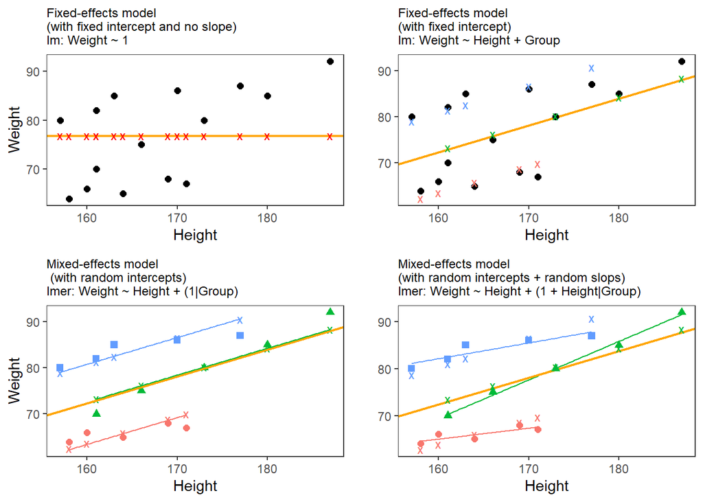

## Preposition use across time

```r
# load packages
library(car)
library(tidyverse)
# load functions
source("https://slcladal.github.io/rscripts/slrsummary.r")
```

After preparing our session, we can now load and inspect the data to get a first impression of its properties.

```r
# load data
slrdata <- base::readRDS(url("https://slcladal.github.io/data/lmm.rda", "rb"))
```

First 20 rows of slrdata.

| Date | Genre | Text | Prepositions | Region |
| --- | --- | --- | --- | --- |
| 1736 | Science | albin | 166.01 | North |
| 1711 | Education | anon | 139.86 | North |
| 1808 | PrivateLetter | austen | 130.78 | North |
| 1878 | Education | bain | 151.29 | North |
| 1743 | Education | barclay | 145.72 | North |
| 1908 | Education | benson | 120.77 | North |
| 1906 | Diary | benson | 119.17 | North |
| 1897 | Philosophy | boethja | 132.96 | North |
| 1785 | Philosophy | boethri | 130.49 | North |
| 1776 | Diary | boswell | 135.94 | North |
| 1905 | Travel | bradley | 154.20 | North |
| 1711 | Education | brightland | 149.14 | North |
| 1762 | Sermon | burton | 159.71 | North |
| 1726 | Sermon | butler | 157.49 | North |
| 1835 | PrivateLetter | carlyle | 124.16 | North |
| 1837 | History | carlyle | 134.48 | North |
| 1774 | Education | chapman | 153.54 | North |
| 1776 | Travel | cook | 140.22 | North |
| 1712 | Travel | cooke | 150.00 | North |
| 1719 | Fiction | defoe | 131.48 | North |

We will now plot the data to get a better understanding of what the data looks like.

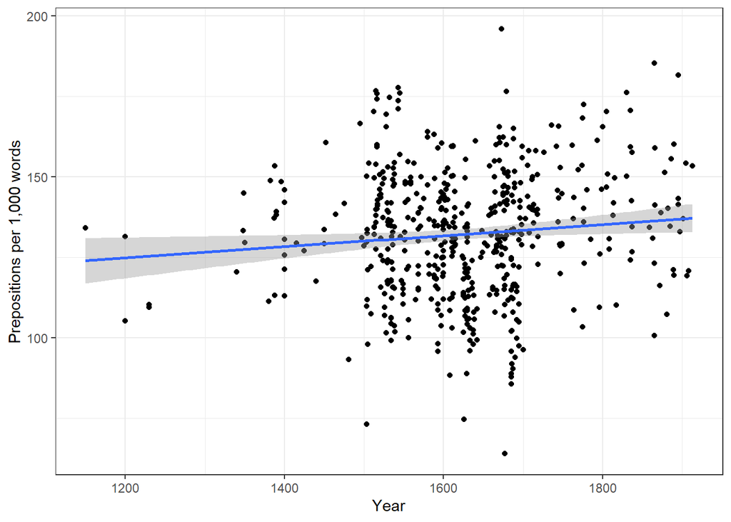

```r
ggplot(slrdata, aes(Date, Prepositions)) +
  geom_point() +
  theme_bw() +
  labs(x = "Year") +
  labs(y = "Prepositions per 1,000 words") +
  geom_smooth(method = "lm") # with linear model smoothing!
```

We now start the statistical analysis by generating a first regression model.

```r
# create initial model
m1.lm <- lm(Prepositions ~ Date, data = slrdata)
# inspect results
summary(m1.lm)
```

```
##
## Call:
## lm(formula = Prepositions ~ Date, data = slrdata)
##
## Residuals:
##         Min          1Q      Median          3Q         Max
## -69.1012471 -13.8549421   0.5779091  13.3208913  62.8580401
##
## Coefficients:
##                    Estimate      Std. Error t value             Pr(>|t|)
## (Intercept) 104.02258335775  11.84756681931 8.78008 < 0.0000000000000002 ***
## Date          0.01732180307   0.00726746646 2.38347             0.017498 *
## ---
## Signif. codes:  0 '***' 0.001 '**' 0.01 '*' 0.05 '.' 0.1 ' ' 1
##
## Residual standard error: 19.4339648 on 535 degrees of freedom
## Multiple R-squared:  0.010507008,    Adjusted R-squared:  0.00865748837
## F-statistic: 5.68093894 on 1 and 535 DF,  p-value: 0.017498081
```

The Estimate for the intercept is the value of y at x = 0 (or, if the y-axis is located at x = 0, the value of y where the regression line crosses the y-axis).

The estimate for Date represents the slope of the regression line and tells us that with each year, the predicted frequency of prepositions increase by .01732 prepositions. The t-value is the Estimate divided by the standard error (Std. Error). Based on the t-value, the p-value can be calculated manually as shown below.

```r
# use pt function (which uses t-values and the degrees of freedom)
2*pt(-2.383, nrow(slrdata)-1)
```

```
## [1] 0.0175196401501
```

The R<sup>2</sup>-values tell us how much variance is explained by our model. The baseline value represents a model that uses merely the mean. 0.0105 means that our model explains only 1.05 percent of the variance (0.010 x 100) - which is a tiny amount. The problem of the multiple R<sup>2</sup> is that it will increase even if we add variables that explain almost no variance. Hence, multiple R<sup>2</sup> encourages the inclusion of *junk* variables.

multiple R<sup>2</sup> = $\frac{Null Deviance - Residual Deviance}{Null Deviance} = 1 - \frac{\sum (y_i - \hat{y_i})^2}{\sum (y_i - \bar y)^2}$

The adjusted R<sup>2</sup>-value takes the number of predictors into account and, thus, the adjusted R<sup>2</sup> will always be lower than the multiple R<sup>2</sup>. This is so because the adjusted R<sup>2</sup> penalizes models for having predictors. The equation for the adjusted R<sup>2</sup> below shows that the amount of variance that is explained by all the variables in the model (the top part of the fraction) must outweigh the inclusion of the number of variables (k) and the number of observations (N). Thus, the adjusted R<sup>2</sup> will decrease when variables are added that explain little or even no variance while it will increase if variables are added that explain a lot of variance.

adjusted R<sup>2</sup> = $1 - (\frac{(1 - R^2)(N - 1)}{N - k - 1})$

If there is a big difference between the two R<sup>2</sup>-values, then the model contains (many) predictors that do not explain much variance which is not good. The F-statistic and the associated p-value tell us that the model, despite explaining almost no variance, is still significantly better than an intercept-only base-line model (or using the overall mean to predict the frequency of prepositions per text).

We can test this and also see where the F-values comes from by comparing our current model to the null-model (the model with only the intercept as a predictor).

```r
# create intercept-only base-line model
m0.lm <- lm(Prepositions ~ 1, data = slrdata)
# compare the base-line and the more saturated model
anova(m0.lm, m1.lm, test = "F")
```

```
## Analysis of Variance Table
##
## Model 1: Prepositions ~ 1
## Model 2: Prepositions ~ Date
##   Res.Df         RSS Df  Sum of Sq       F   Pr(>F)
## 1    536 204203.8289
## 2    535 202058.2576  1 2145.57126 5.68094 0.017498 *
## ---
## Signif. codes:  0 '***' 0.001 '**' 0.01 '*' 0.05 '.' 0.1 ' ' 1
```

The F- and p-values are exactly those reported by the summary which shows where the F-values comes from and what they mean; namely they denote the difference between the base-line and the more saturated model.

The degrees of freedom associated with the residual standard error are the number of cases in the model minus the number of predictors (including the intercept). The residual standard error is the square root of the sum of the squared residuals of the model divided by the degrees of freedom. Have a look at he following to clear this up:

```r
# DF = N - number of predictors (including intercept)
DegreesOfFreedom <- nrow(slrdata)-length(coef(m1.lm))
# sum of the squared residuals
SumSquaredResiduals <- sum(resid(m1.lm)^2)
# F-value
Fvalue <- coef(summary(m1.lm))[6]^2
# Residual Standard Error
sqrt(SumSquaredResiduals/DegreesOfFreedom); DegreesOfFreedom; Fvalue; SumSquaredResiduals
```

```
## [1] 19.4339647585
```

```
## [1] 535
```

```
## [1] 5.68093894074
```

```
## [1] 202058.257635
```

## Model fitting and assumptions

We will now check if mathematical assumptions have been violated (homogeneity of variance) or whether the data contains outliers. We check this using diagnostic plots.

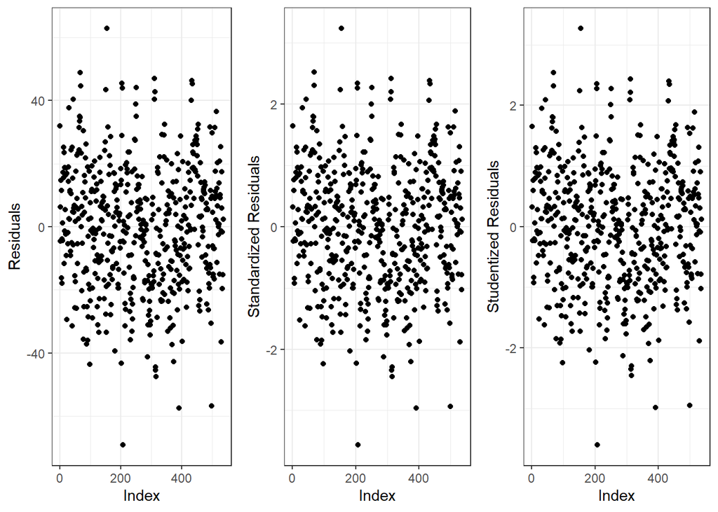

```r
# generate data
df2 <- data.frame(id = 1:length(resid(m1.lm)),
                 residuals = resid(m1.lm),
                 standard = rstandard(m1.lm),
                 studend = rstudent(m1.lm))
# generate plots
p1 <- ggplot(df2, aes(x = id, y = residuals)) +
  theme(panel.grid.major = element_blank(), panel.grid.minor = element_blank()) +
  geom_point() +
  labs(y = "Residuals", x = "Index") +
  theme_bw()
p2 <- ggplot(df2, aes(x = id, y = standard)) +
  theme(panel.grid.major = element_blank(), panel.grid.minor = element_blank()) +
  geom_point() +
  labs(y = "Standardized Residuals", x = "Index") +
  theme_bw()
p3 <- ggplot(df2, aes(x = id, y = studend)) +
  theme(panel.grid.major = element_blank(), panel.grid.minor = element_blank()) +
  geom_point() +
  labs(y = "Studentized Residuals", x = "Index") +
  theme_bw()
# display plots
ggpubr::ggarrange(p1, p2, p3, ncol = 3, nrow = 1)
```

The left graph shows the residuals of the model (i.e., the differences between the observed and the values predicted by the regression model). The problem with this plot is that the residuals are not standardized and so they cannot be compared to the residuals of other models. To remedy this deficiency, residuals are normalized by dividing the residuals by their standard deviation. Then, the normalized residuals can be plotted against the observed values (centre panel). In this way, not only are standardized residuals obtained, but the values of the residuals are transformed into z-values, and one can use the z-distribution to find problematic data points. There are three rules of thumb regarding finding problematic data points through standardized residuals (Field, Miles, and Field 2012, 268–69):

- Points with values higher than 3.29 should be removed from the data.
- If more than 1% of the data points have values higher than 2.58, then the error rate of our model is too high.
- If more than 5% of the data points have values greater than 1.96, then the error rate of our model is too high.

The right panel shows the *studentized residuals* (adjusted predicted values: each data point is divided by the standard error of the residuals). In this way, it is possible to use Student’s t-distribution to diagnose our model.

Adjusted predicted values are residuals of a special kind: the model is calculated without a data point and then used to predict this data point. The difference between the observed data point and its predicted value is then called the adjusted predicted value. In summary, studentized residuals are very useful because they allow us to identify influential data points.

The plots show that there are two potentially problematic data points (the top-most and bottom-most point). These two points are clearly different from the other data points and may therefore be outliers. We will test later if these points need to be removed.

A few words on leverage as this is an importnat concept when determining if data points represent outiers. Leverage values range between 0 (no influence) and 1 (strong influence: suboptimal!). To test whether a specific data point has a high leverage value, we calculate a cut-off point that indicates whether the leverage is too strong or still acceptable. The following two formulas are used for this (N = number of cases in model, k = number of predictors in model (including the intercept)):

Leverage<sub>cutoff</sub> = $\frac{3(k + 1)}{n} | \frac{2(k + 1)}{n} = \frac{3(2 + 1)}{537} = \frac{9}{537}$ = 0.01676

We will now generate more diagnostic plots to check for potential probelms.

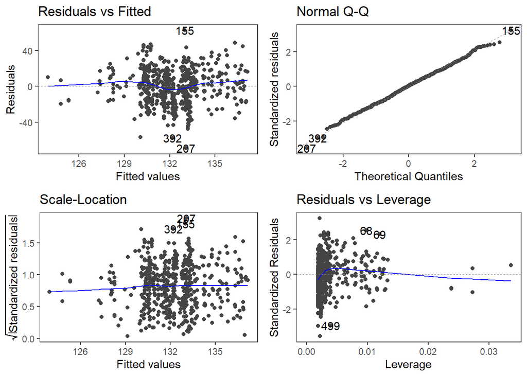

```r
# load package
library(ggfortify)
# generate plots
autoplot(m1.lm) +
  theme_bw() +
  theme(panel.grid.major = element_blank(), panel.grid.minor = element_blank())
```

The graph in the upper left panel is useful for finding outliers or for determining the correlation between residuals and predicted values: when a trend becomes visible in the line or points (e.g., a rising trend or a zigzag line), then this would indicate that the model would be problematic.

The graphic in the upper right panel indicates whether the residuals are normally distributed (the points lie on the line) or whether the residuals do not follow a normal distribution (points are not on the line at the top and bottom).

The graphic in the lower left panel provides information about *homoscedasticity*. Homoscedasticity means that the variance of the residuals remains constant and does not correlate with any independent variable. In unproblematic cases, the graphic shows a flat line. If there is a trend in the line or if the points for a funnel-like shape, then we are dealing with heteroscedasticity (correlation between independent variables and the residuals), which is very problematic for regressions.

The graph in the lower right panel shows problematic influential data points that disproportionately affect the regression (leverage). If such influential data points are present, they should be either weighted (one could generate a robust rather than a simple linear regression) or they must be removed. The graph displays Cook’s distance and data points that have a Cook’s distance value greater than 1 are problematic (Field, Miles, and Field 2012, 269).

We will end the current analysis by summarizing the results of the regression analysis in a table.

```r
# create summary table
slrsummary(m1.lm)
```

Results of a simple linear regression analysis.

|  | Estimate | Pearson’s r | Std. Error | t value | Pr(>\|t\|) | P-value sig. |
| --- | --- | --- | --- | --- | --- | --- |
| (Intercept) | 104.02 |  | 11.85 | 8.78 | 0 | p < .001*** |
| Date | 0.02 | 0.1 | 0.01 | 2.38 | 0.0175 | p < .05* |
| Model statistics |  |  |  |  |  | Value |
| Number of cases in model |  |  |  |  |  | 537 |
| Residual standard error on 535 DF |  |  |  |  |  | 19.43 |
| Multiple R-squared |  |  |  |  |  | 0.0105 |
| Adjusted R-squared |  |  |  |  |  | 0.0087 |
| F-statistic (1, 535) |  |  |  |  |  | 5.68 |
| Model p-value |  |  |  |  |  | 0.0175 |

An alternative but less informative summary table of the results of a regression analysis can be generated using the `tab_model` function from the `sjPlot` package (as is shown below).

```r
#load package
library(sjPlot)
# generate summary table
sjPlot::tab_model(m1.lm)
```

|  | Prepositions |  |  |
| --- | --- | --- | --- |
| Predictors | Estimates | CI | p |
| (Intercept) | 104.02 | 80.75 – 127.30 | **<0.001** |
| Date | 0.02 | 0.00 – 0.03 | **0.017** |
| Observations | 537 |  |  |
| R<sup>2</sup> / R<sup>2</sup> adjusted | 0.011 / 0.009 |  |  |

The results of simple linear regressions can be written up is provided below.

A simple linear regression has been fitted to the data. A visual assessment of the model diagnostic graphics did not indicate any problematic or disproportionately influential data points (outliers) and performed significantly better compared to an intercept-only base line model but only explained .87 percent of the variance (adjusted R<sup>2</sup>: .0087, F-statistic (1, 535): 5,68, p-value: 0.0175*). The final minimal adequate linear regression model is based on 537 data points and confirms a significant and positive correlation between the year in which the text was written and the relative frequency of prepositions (coefficient estimate (logged odds): .02, SE: 0.01, t-value: 2.38, p-value: .0175*).

> Question Time! What frequency of prepositions does the model predict for the year 0 and does it make sense to have a value predicted for the year 0 when English only started with the first Germanic invasion of Britannia in app. 450?

**Answer**

The model predicts that a text written in the year zero would contain 104.02 prepositions per 1,000 words (the intercept) and, clearly, this does not make sense. In fact, when you think of the example with Height and Weight, the model would predict that a person that is 0(!) cm tall would weigh negative 93.77 kg and that with every centimeter, that person would increase by 0.98 kg in weight - so any baby or child under app. 95 centimeters would be lighter than air. This clearly does not make sense, which shows that you always have to perform a sanity check on what you model reports and in which conditions (and ranges) your model makes sense and where not!

# Practical Examples

In contrast to fixed-effects regression models, mixed-effects models assume a hierarchical data structure in which data points are grouped or nested in higher order categories (e.g. students within classes). Mixed-effects models are rapidly increasing in use in data analysis because they allow us to incorporate hierarchical or nested data structures. Mixed-effects models are, of course, an extension of fixed-effects regression models and also multivariate and come in different types.

In the following, we will go over the most relevant and frequently used types of mixed-effect regression models, mixed-effects linear regression models and mixed-effects binomial logistic regression models.

The major difference between these types of models is that they take different types of dependent variables. While linear models take numeric dependent variables, logistic models take nominal variables.

## Linear Mixed-Effects Regression

The following focuses on an extension of ordinary multiple linear regressions: mixed-effects regression linear regression. Mixed-effects models have the following advantages over simpler statistical tests:

- Mixed-effects models are multivariate, i.e. they test the effect of several predictors simultaneously while controlling for the effect of all other predictors.
- Mixed models allow to statistically incorporate within-speaker variability and are thus fit to model hierarchical or nested data structures. This applies if several observations are produced by an individual speaker, for instance.
- Mixed-models provide useful diagnostic statistics which enables us to control e.g. (multi-)collinearity, i.e. predictability of predictors by other predictors (see [here](https://slcladal.github.io/,col.html) for an explanation of (multi-)collinearity), and to test whether conditions or requirements are violated (e.g. homogeneity of variance, etc.).

Major disadvantages of mixed-effects regression modeling are that they are prone to producing high $\beta$-errors (see Johnson 2009) and that they require rather large data sets.

### Introduction

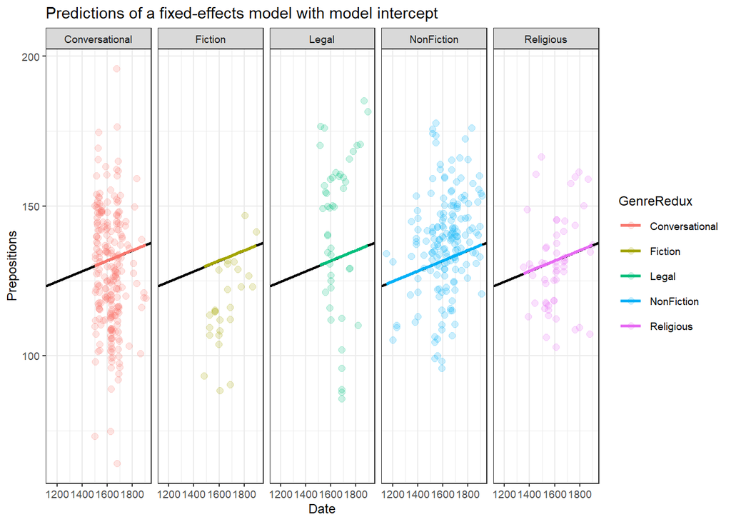

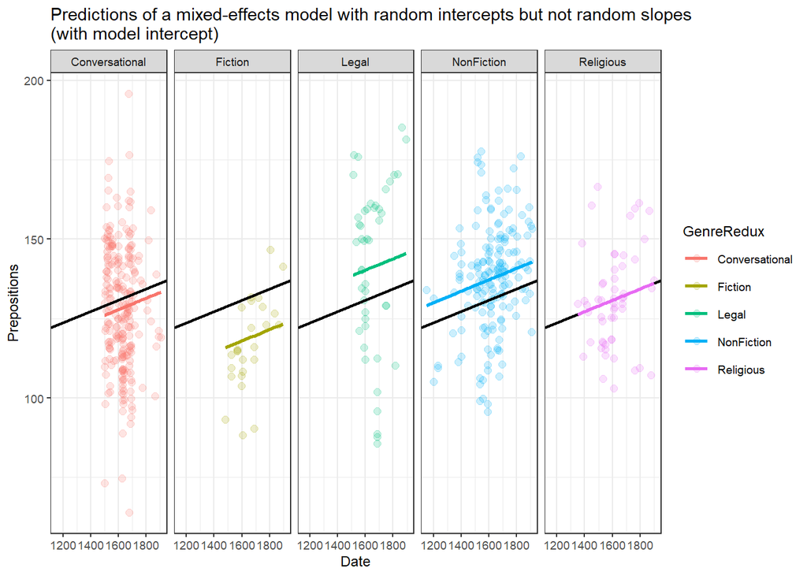

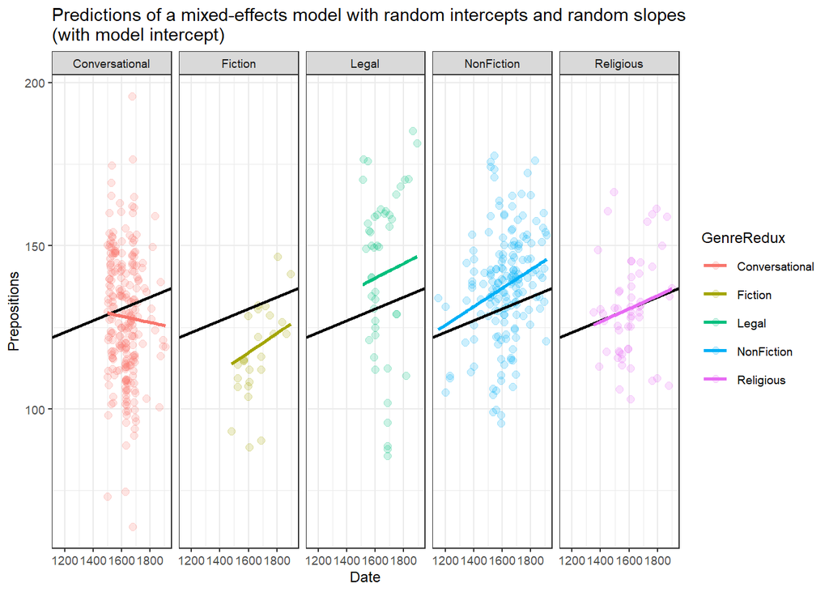

### Random Effects

*Random Effects* can be visualized using two parameters: the intercept (the point where the regression line crosses the y-axis at x equals 0) and the slope (the acclivity of the regression line). In contrast to fixed-effects models, that have only 1 intercept and one slope (top figure), mixed-effects models can therefore have various *random intercepts* (middle figure) or various *random slopes*, or both, various *random intercepts* and various *random slopes* (bottom figure).

What features do distinguish random and fixed effects?

1. Random effects represent a higher level variable under which data points are *grouped*(!). This implies that random effects must be categorical (or nominal but *they cannot be continuous*!) (see Winter 2019, 236).
2. Random effects represent a sample of an infinite number of possible levels. For instance, speakers, trials, items, subjects, or words represent a potentially infinite pool of elements from which many different samples can be drawn. Thus, random effects represent a random sample. Fixed effects, on the other hand, typically do not represent a random sample but a fixed set of variable levels (e.g. Age groups, or parts-of-speech).
3. Random effects typically represent many different levels while fixed effects typically have only a few. Zuur, Hilbe, and Ieno (2013) propose that a variable may be used as a fixed effect if it has less than 5 levels while it should be treated as a random effect if it has more than 10 levels. Variables with 5 to 10 levels can be used as both. However, this is a rule of thumb and ignores the theoretical reasons (random sample and nestedness) for considering something as a random effect and it also is at odds with the way that repeated measures are models (namely as mixed effects) although they typically only have very few levels.
4. Fixed effects represent an effect that if we draw many samples, the effect would be consistent across samples (Winter 2019) while random effects should vary for each new sample that is drawn.

Models with only random intercepts are more common because including both random intercepts and random slopes requires larger data sets (but have a better fit because intercepts are not forced to be parallel and the lines therefore have a better fit). Always think about what random effects structure is appropriate for your model (see Winter 2019, 241–44). Mixed-effects are called mixed-effects because they contain both random and fixed effects and during model fitting, random effects are added first.

### Example: Preposition Use across Time by Genre

To explore how to implement a mixed-effects model in R we revisit the preposition data that contains relative frequencies of prepositions in English texts written between 1150 and 1913. As a first step, and to prepare our analysis, we load necessary R packages, specify options, and load as well as provide an overview of the data.

```r
# suppress scientific notation
options("scipen" = 100, "digits" = 4)
# do not convert strings into factors
options(stringsAsFactors = F)
# load packages
library(lme4)
library(lmerTest)
# read in data
lmmdata  <- base::readRDS(url("https://slcladal.github.io/data/lmm.rda", "rb")) %>%
# convert date into a numeric variable
    dplyr::mutate(Date = as.numeric(Date))
```

First 20 rows of lmmdata.

| Date | Genre | Text | Prepositions | Region |
| --- | --- | --- | --- | --- |
| 1736 | Science | albin | 166.0 | North |
| 1711 | Education | anon | 139.9 | North |
| 1808 | PrivateLetter | austen | 130.8 | North |
| 1878 | Education | bain | 151.3 | North |
| 1743 | Education | barclay | 145.7 | North |
| 1908 | Education | benson | 120.8 | North |
| 1906 | Diary | benson | 119.2 | North |
| 1897 | Philosophy | boethja | 133.0 | North |
| 1785 | Philosophy | boethri | 130.5 | North |
| 1776 | Diary | boswell | 135.9 | North |
| 1905 | Travel | bradley | 154.2 | North |
| 1711 | Education | brightland | 149.1 | North |
| 1762 | Sermon | burton | 159.7 | North |
| 1726 | Sermon | butler | 157.5 | North |
| 1835 | PrivateLetter | carlyle | 124.2 | North |
| 1837 | History | carlyle | 134.5 | North |
| 1774 | Education | chapman | 153.5 | North |
| 1776 | Travel | cook | 140.2 | North |
| 1712 | Travel | cooke | 150.0 | North |
| 1719 | Fiction | defoe | 131.5 | North |

The data set contains the date when the text was written (Date), the genre of the text (Genre), the name of the text (Text), the relative frequency of prepositions in the text (Prepositions), and the region in which the text was written (Region). We now plot the data to get a first impression of its structure.

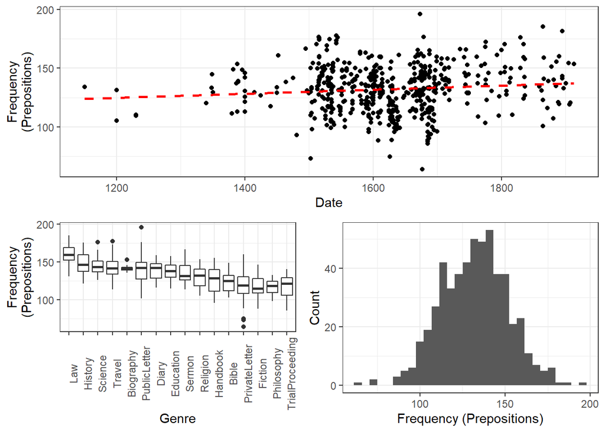

```r
p1 <- ggplot(lmmdata, aes(x = Date, y = Prepositions)) +
  geom_point() +
  geom_smooth(method = "lm", se = F, color = "red", linetype = "dashed") +
  theme_bw() +
  labs(y = "Frequency\n(Prepositions)")
p2 <- ggplot(lmmdata, aes(x = reorder(Genre, -Prepositions), y = Prepositions)) +
  geom_boxplot() +
  theme_bw() +
  theme(axis.text.x = element_text(angle=90)) +
  labs(x = "Genre", y = "Frequency\n(Prepositions)")
p3 <- ggplot(lmmdata, aes(Prepositions)) +
  geom_histogram() +
  theme_bw() +
  labs(y = "Count", x = "Frequency (Prepositions)")
grid.arrange(grobs = list(p1, p2, p3), widths = c(1, 1), layout_matrix = rbind(c(1, 1), c(2, 3)))
```

The scatter plot in the upper panel indicates that the use of prepositions has moderately increased over time while the boxplots in the lower left panel show that the genres differ quite substantially with respect to their median frequencies of prepositions per text. Finally, the histogram in the lower right panel show that preposition use is distributed normally with a mean of 132.2 prepositions per text.

Centering or even scaling numeric variables is useful for later interpretation of regression models: if the date variable were not centered, the regression would show the effects of variables at year 0(!). If numeric variables are centered, other variables are variables are considered relative not to 0 but to the mean of that variable (in this case the mean of years in our data). Centering simply means that the mean of the numeric variable is subtracted from each value.

```r
lmmdata$DateUnscaled <- lmmdata$Date
lmmdata$Date <- scale(lmmdata$Date, scale = F)
```

First 5 rows of lmmdata.

| Date | Genre | Text | Prepositions | Region | DateUnscaled |
| --- | --- | --- | --- | --- | --- |
| 109.87 | Science | albin | 166.0 | North | 1736 |
| 84.87 | Education | anon | 139.9 | North | 1711 |
| 181.87 | PrivateLetter | austen | 130.8 | North | 1808 |
| 251.87 | Education | bain | 151.3 | North | 1878 |
| 116.87 | Education | barclay | 145.7 | North | 1743 |

We now set up a fixed-effects model with the `glm` function from the `stats`and a mixed-effects model with *Genre* as a random effect using the `lmer` function from the `lme4` package.

```r
# Load package
library(lme4)
# generate models
m0.glm <- glm(Prepositions ~ 1, family = gaussian, data = lmmdata)
m0.lmer = lmer(Prepositions ~ 1 + (1|Genre), data = lmmdata)
```

Now that we have created the base-line models, we will test whether including a random effect structure is mathematically justified. It is important to note here that we are not going to test if including a random effect structure is theoretically motivated but simply if it causes a decrease in variance.

### Testing Random Effects

As a first step in the modeling process, we now need to determine whether or not including a random effect structure is justified. We do so by comparing the AIC of the base-line model without random intercepts to the AIC of the model with random intercepts.

```r
AIC(logLik(m0.glm))
```

```
## [1] 4718
```

```r
AIC(logLik(m0.lmer))
```

```
## [1] 4498
```

The inclusion of a random effect structure with random intercepts is justified as the AIC of the model with random intercepts is substantially lower than the AIC of the model without random intercepts.

While I do not how how to *test* if including a random effect is justified, there are often situations, which require to test exactly which random effect structure is best. When doing this, it is important to use *restricted maximum likelihood* (`REML = TRUE` or `method = REML`) rather than maximum likelihood (see Pinheiro and Bates 2000; Winter 2019, 226).

```r
# generate models with 2 different random effect structures
ma.lmer = lmer(Prepositions ~ Date + (1|Genre), REML = T, data = lmmdata)
mb.lmer = lmer(Prepositions ~ Date + (1 + Date | Genre), REML = T, data = lmmdata)
# compare models
anova(ma.lmer, mb.lmer, test = "Chisq", refit = F)
```

```
## Data: lmmdata
## Models:
## ma.lmer: Prepositions ~ Date + (1 | Genre)
## mb.lmer: Prepositions ~ Date + (1 + Date | Genre)
##         npar  AIC  BIC logLik deviance Chisq Df Pr(>Chisq)
## ma.lmer    4 4499 4516  -2246     4491
## mb.lmer    6 4487 4512  -2237     4475  16.4  2    0.00027 ***
## ---
## Signif. codes:  0 '***' 0.001 '**' 0.01 '*' 0.05 '.' 0.1 ' ' 1
```

The model comparison shows that the model with the more complex random effect structure has a significantly better fit to the data compared with the model with the simpler random effect structure but the more complex model fails to converge. In this case, we would test if scaling numeric variables and another optimizer would remedy this issue. However, if this issue cannot be resolved, we would have to stick to the model with the random effect structure that does not cause issues. In this example, we will not try to solve the issues with the complex random effect structure and simply continue with the model with the simpler structure.

> Note: the model with the random slopes causes a warning (not shown here) informing us that the model failed to converge. If this happens, the results of this model cannot be trusted. While we would switch to a model with a significantly better fit to the data, we would only do so if the model is reliable (which is not the case with the random slope model).

### Model Fitting

After having determined that including a random effect structure is justified, we can continue by fitting the model and including diagnostics as we go. Including diagnostics in the model fitting process can save time and prevent relying on models which only turn out to be unstable if we would perform the diagnostics after the fact.

We begin fitting our model by adding Date as a fixed effect and compare this model to our mixed-effects base-line model to see if Date improved the model fit by explaining variance and if Date significantly correlates with our dependent variable (this means that the difference between the models is the effect (size) of “Date”!)

```r
m1.lmer <- lmer(Prepositions ~ (1|Genre) + Date, data = lmmdata)
anova(m1.lmer, m0.lmer, test = "Chi")
```

```
## refitting model(s) with ML (instead of REML)
```

```
## Data: lmmdata
## Models:
## m0.lmer: Prepositions ~ 1 + (1 | Genre)
## m1.lmer: Prepositions ~ (1 | Genre) + Date
##         npar  AIC  BIC logLik deviance Chisq Df Pr(>Chisq)
## m0.lmer    3 4502 4515  -2248     4496
## m1.lmer    4 4495 4512  -2244     4487  8.93  1     0.0028 **
## ---
## Signif. codes:  0 '***' 0.001 '**' 0.01 '*' 0.05 '.' 0.1 ' ' 1
```

The model with Date is the better model (significant p-value and lower AIC). The significant p-value shows that *Date* correlates significantly with *Prepositions* ($\chi$<sup>2</sup>(1) = 8.93, p = .0028). The $\chi$<sup>2</sup> value here is labeled *Chisq* and the degrees of freedom are calculated by subtracting the smaller number of DFs from the larger number of DFs.

We now test whether Region should also be part of the final minimal adequate model. The easiest way to add predictors is by using the `update` function (it saves time and typing).

```r
# generate model
m2.lmer <- update(m1.lmer, .~.+ Region)
# test vifs
car::vif(m2.lmer)
```

```
##   Date Region
##  1.203  1.203
```

```r
# compare models
anova(m2.lmer, m1.lmer, test = "Chi")
```

```
## refitting model(s) with ML (instead of REML)
```

```
## Data: lmmdata
## Models:
## m1.lmer: Prepositions ~ (1 | Genre) + Date
## m2.lmer: Prepositions ~ (1 | Genre) + Date + Region
##         npar  AIC  BIC logLik deviance Chisq Df Pr(>Chisq)
## m1.lmer    4 4495 4512  -2244     4487
## m2.lmer    5 4495 4516  -2242     4485  2.39  1       0.12
```

Three things tell us that Region should not be included: (i) the AIC does not decrease, (ii) the BIC increases(!), and the p-value is higher than .05. This means, that we will continue fitting the model without having Region included. Well… not quite - just as a note on including variables: while Region is not significant as a main effect, it must still be included in a model if it were part of a significant interaction. To test if this is indeed the case, we fit another model with the interaction between Date and Region as predictor.

```r
# generate model
m3.lmer <- update(m1.lmer, .~.+Region*Date)
# extract vifs
car::vif(m3.lmer)
```

```
##        Date      Region Date:Region
##       1.969       1.203       1.780
```

```r
# compare models
anova(m3.lmer, m1.lmer, test = "Chi")
```

```
## refitting model(s) with ML (instead of REML)
```

```
## Data: lmmdata
## Models:
## m1.lmer: Prepositions ~ (1 | Genre) + Date
## m3.lmer: Prepositions ~ (1 | Genre) + Date + Region + Date:Region
##         npar  AIC  BIC logLik deviance Chisq Df Pr(>Chisq)
## m1.lmer    4 4495 4512  -2244     4487
## m3.lmer    6 4496 4522  -2242     4484  2.89  2       0.24
```

Again, the high p-value and the increase in AIC and BIC show that we have found our minimal adequate model with only contains Date as a main effect. In a next step, we can inspect the final minimal adequate model, i.e. the most parsimonious (the model that explains a maximum of variance with a minimum of predictors).

```r
# inspect results
summary(m1.lmer)
```

```
## Linear mixed model fit by REML. t-tests use Satterthwaite's method [
## lmerModLmerTest]
## Formula: Prepositions ~ (1 | Genre) + Date
##    Data: lmmdata
##
## REML criterion at convergence: 4491
##
## Scaled residuals:
##    Min     1Q Median     3Q    Max
## -3.735 -0.657  0.006  0.661  3.597
##
## Random effects:
##  Groups   Name        Variance Std.Dev.
##  Genre    (Intercept) 159      12.6
##  Residual             229      15.1
## Number of obs: 537, groups:  Genre, 16
##
## Fixed effects:
##              Estimate Std. Error        df t value            Pr(>|t|)
## (Intercept) 133.88516    3.24749  14.98898    41.2 <0.0000000000000002 ***
## Date          0.01894    0.00632 533.85193     3.0              0.0029 **
## ---
## Signif. codes:  0 '***' 0.001 '**' 0.01 '*' 0.05 '.' 0.1 ' ' 1
##
## Correlation of Fixed Effects:
##      (Intr)
## Date 0.005
```

And for comparison, the results of a fixed-effects a generalized linear model that was fit to the same data.

```r
# inspect results
summary(glm(Prepositions ~ Date + Genre, data = lmmdata))
```

```
##
## Call:
## glm(formula = Prepositions ~ Date + Genre, data = lmmdata)
##
## Deviance Residuals:
##    Min      1Q  Median      3Q     Max
## -56.34   -9.83    0.02   10.19   54.27
##
## Coefficients:
##                       Estimate Std. Error t value             Pr(>|t|)
## (Intercept)          123.56355    3.38523   36.50 < 0.0000000000000002 ***
## Date                   0.01894    0.00639    2.96               0.0032 **
## GenreBiography        17.57890    5.53609    3.18               0.0016 **
## GenreDiary            14.60240    4.44177    3.29               0.0011 **
## GenreEducation        12.33439    4.41702    2.79               0.0054 **
## GenreFiction          -7.20526    4.51180   -1.60               0.1109
## GenreHandbook          2.68200    4.50958    0.59               0.5523
## GenreHistory          26.04134    4.36652    5.96   0.0000000045540179 ***
## GenreLaw              36.09630    4.47210    8.07   0.0000000000000048 ***
## GenrePhilosophy       -6.82719    5.52617   -1.24               0.2172
## GenrePrivateLetter    -4.21905    3.62602   -1.16               0.2451
## GenrePublicLetter     17.13741    3.80647    4.50   0.0000083089215312 ***
## GenreReligion         11.79614    5.33012    2.21               0.0273 *
## GenreScience          20.05315    4.87300    4.12   0.0000449829699106 ***
## GenreSermon           12.10449    4.24000    2.85               0.0045 **
## GenreTravel           19.99791    4.47275    4.47   0.0000095626092532 ***
## GenreTrialProceeding  -7.69645    4.85385   -1.59               0.1134
## ---
## Signif. codes:  0 '***' 0.001 '**' 0.01 '*' 0.05 '.' 0.1 ' ' 1
##
## (Dispersion parameter for gaussian family taken to be 228.8)
##
##     Null deviance: 204204  on 536  degrees of freedom
## Residual deviance: 118962  on 520  degrees of freedom
## AIC: 4460
##
## Number of Fisher Scoring iterations: 2
```

As well as the results of a mixed-effects model with random intercepts and random slopes.

```r
# inspect results
summary(lmer(Prepositions ~ (1 + Date | Genre ) + Date, data = lmmdata))
```

```
## Linear mixed model fit by REML. t-tests use Satterthwaite's method [
## lmerModLmerTest]
## Formula: Prepositions ~ (1 + Date | Genre) + Date
##    Data: lmmdata
##
## REML criterion at convergence: 4475
##
## Scaled residuals:
##    Min     1Q Median     3Q    Max
## -3.733 -0.693  0.024  0.633  3.724
##
## Random effects:
##  Groups   Name        Variance Std.Dev. Corr
##  Genre    (Intercept) 269.1681 16.4063
##           Date          0.0017  0.0412  0.20
##  Residual             210.8813 14.5218
## Number of obs: 537, groups:  Genre, 16
##
## Fixed effects:
##             Estimate Std. Error       df t value     Pr(>|t|)
## (Intercept) 134.2922     4.2017   7.0710   31.96 0.0000000066 ***
## Date          0.0234     0.0124  12.4706    1.89        0.082 .
## ---
## Signif. codes:  0 '***' 0.001 '**' 0.01 '*' 0.05 '.' 0.1 ' ' 1
##
## Correlation of Fixed Effects:
##      (Intr)
## Date 0.169
## optimizer (nloptwrap) convergence code: 0 (OK)
## Model failed to converge with max|grad| = 2.14514 (tol = 0.002, component 1)
## Model is nearly unidentifiable: very large eigenvalue
##  - Rescale variables?
```

The summary output starts by informing us that the model used a *RE*stricted *M*aximum *L*ikelihood (REML) criterion rather than the *M*aximum *L*ikelihood (ML) or the *L*og-*L*ikelihood (LL) criterion for optimization of parameter estimates (see [here](https://towardsdatascience.com/maximum-likelihood-ml-vs-reml-78cf79bef2cf) for an explanations of REML and ML, what the difference between REML and ML is, and why we use REML here). The output then states the model formula (see [here](https://it.unt.edu/sites/default/files/linearmixedmodels_jds_dec2010.pdf) for an elaborate explanation of the output of mixed-effects linear regressions). Then, the output provides us with a value for the REML criterion when the model converged. We then get an overview of the distribution of scaled residuals. This should be symmetric(!) - if the values are not symmetric, then the model contains outliers or the data violate model assumptions. Next, we get an overview of the random effects that the model contained and their variances, followed by an overview of the estimates of the fixed effects. We will now focus a bit more thoroughly on what these values - especially the variances for the random effects mean (what the estimates of the fixed-effects means should be clear from what we have discussed above - the intercept represents the y-axis point at x=0 and the estimates represent the slopes for the fixed effects).

But given that we are dealing with a mixed-effects model that uses many intercepts (rather than juts 1): what are the intercepts and the slope for the different genres?

```r
coef(m1.lmer)
```

```
## $Genre
##                 (Intercept)    Date
## Bible                 124.3 0.01894
## Biography             140.4 0.01894
## Diary                 138.0 0.01894
## Education             135.8 0.01894
## Fiction               117.3 0.01894
## Handbook              126.6 0.01894
## History               148.9 0.01894
## Law                   158.4 0.01894
## Philosophy            118.6 0.01894
## PrivateLetter         119.5 0.01894
## PublicLetter          140.6 0.01894
## Religion              135.2 0.01894
## Science               142.9 0.01894
## Sermon                135.6 0.01894
## Travel                143.1 0.01894
## TrialProceeding       117.1 0.01894
##
## attr(,"class")
## [1] "coef.mer"
```

We see that the *TrialProceeding* have the lowest intercept (117.1) and thus the lowest relative frequency of prepositions while *Law* has the highest relative frequency of prepositions (158.4). The slope is always the same as we have not defined random slopes in this model.

Now, what does the Variance for *Genre (Intercept)* (159) in the Random Effects section of the output of the linear mixed model mean?

Does it refer to the mean of the coefficients?

```r
mean(coef(m1.lmer)$Genre[,1])
```

```
## [1] 133.9
```

No, this gives us the model intercept. So what do these variance values mean? Well, they represent the amount of variance that is explained by a random effect. Thus, *Genre* explains 159 of the total variance of the random effects ($\hat{\sigma}^2$*total* = 159 + 229 = 388). This also means that the residual deviance is still larger than the variance accounted for by *Genre* which means that *Genre* does not explain the entire variance. But how much explanatory power does *Genre* have? We can calculate the amount of the total variance of the random effects that is explained by a random effect by dividing the variance of a random effect by the total variance:

```r
159/(159+229)
```

```
## [1] 0.4098
```

Before turning to the diagnostics, we will use the fitted (or predicted) and the observed values with a regression line for the predicted values. This will not only show how good the model fit the data but also the direction and magnitude of the effect.

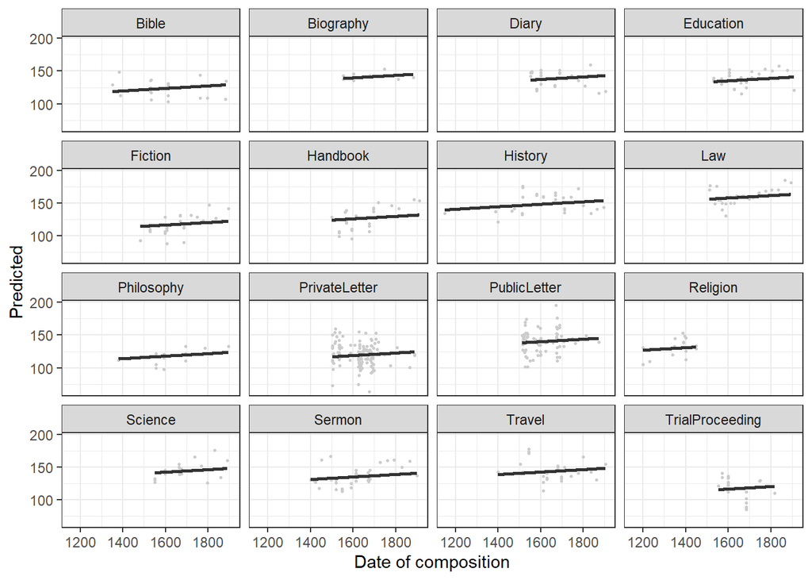

```r
# extract predicted values
lmmdata$Predicted <- predict(m1.lmer, lmmdata)
# plot predicted values
ggplot(lmmdata, aes(DateUnscaled, Predicted)) +
  facet_wrap(~Genre) +
  geom_point(aes(x = DateUnscaled, y = Prepositions), color = "gray80", size = .5) +
  geom_smooth(aes(y = Predicted), color = "gray20", linetype = "solid",
              se = T, method = "lm") +
  guides(color=guide_legend(override.aes=list(fill=NA))) +
  theme_bw(base_size = 10) +
  theme(legend.position="top", legend.title = element_blank(),
        panel.grid.major = element_blank(),
        panel.grid.minor = element_blank()) +
  xlab("Date of composition") +
  theme_bw()
```

### Remarks on Prediction

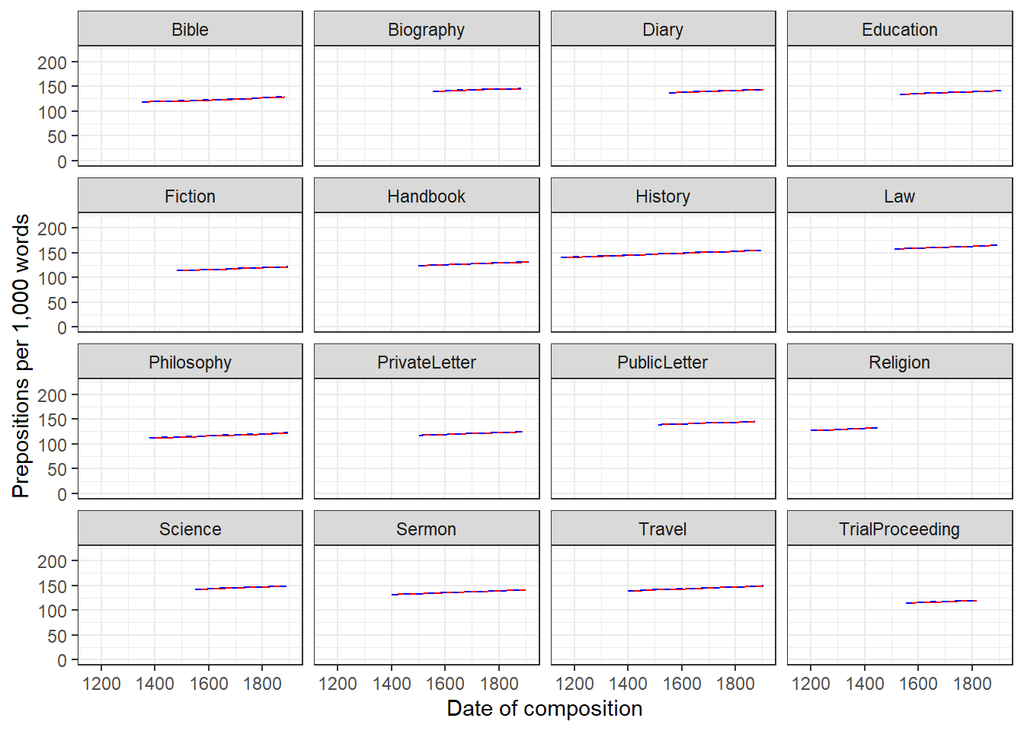

```r
# creat lm model
m5.lmeunweight <- lm(Prepositions ~ DateUnscaled + Genre, data = lmmdata)
lmmdata$lmePredictions <- fitted(m5.lmeunweight, lmmdata)
m5.lm <- lm(Prepositions ~ DateUnscaled + Genre, data = lmmdata)
lmmdata$lmPredictions <- fitted(m5.lm, lmmdata)
# plot predictions
ggplot(lmmdata, aes(x = DateUnscaled, y = lmePredictions, group = Genre)) +
  geom_line(aes(y = lmmdata$lmePredictions), linetype = "solid", color = "red") +
  geom_line(aes(y = lmmdata$lmPredictions), linetype = "dashed", color = "blue") +
  facet_wrap(~ Genre, nrow = 4) +
  theme_bw() +
  labs(x = "Date of composition") +
  labs(y = "Prepositions per 1,000 words") +
  coord_cartesian(ylim = c(0, 220))
```

### Model Diagnostics

Below is a list of criteria that should be considered when diagnosing regression models:

1. Data points with standardized residuals > 3.29 should be removed (Field, Miles, and Field 2012, 269)
2. If more than 1 percent of data points have standardized residuals exceeding values > 2.58, then the error rate of the model is unacceptable (Field, Miles, and Field 2012, 269).
3. If more than 5 percent of data points have standardized residuals exceeding values > 1.96, then the error rate of the model is unacceptable (Field, Miles, and Field 2012, 269)
4. In addition, data points with Cook’s D-values > 1 should be removed (Field, Miles, and Field 2012, 269)
5. Also, data points with leverage values $3(k + 1)/N$ (k = Number of predictors, N = Number of cases in model) should be removed (Field, Miles, and Field 2012, 270)
6. There should not be (any) autocorrelation among predictors. This means that independent variables cannot be correlated with itself (for instance, because data points come from the same subject). If there is autocorrelation among predictors, then a Repeated Measures Design or a (hierarchical) mixed-effects model should be implemented instead.
7. Predictors cannot substantially correlate with each other (multicollinearity) (see [here](https://slcladal.github.io/,col.html) for an explanation of (multi-)collinearity). If a model contains predictors that have variance inflation factors (VIF) > 10 the model is unreliable (Myers 1990) and predictors causing such VIFs should be removed. Indeed, even VIFs of 2.5 can be problematic (Szmrecsanyi 2006, 215; Zuur, Ieno, and Elphick 2010) proposes that variables with VIFs exceeding 3 should be removed!

> Note: however, (multi-)collinearity is only an issue if one is interested in interpreting regression results! If the interpretation is irrelevant because what is relevant is prediction(!), then it does not matter if the model contains collinear predictors! See Gries (2021) for a more elaborate explanation.
8. The mean value of VIFs should be $~$ 1 (Bowerman and O’Connell 1990).

We can now evaluate the goodness of fit of the model and check if mathematical requirements and assumptions have been violated.

In a first step, we inspect the residuals of the model.

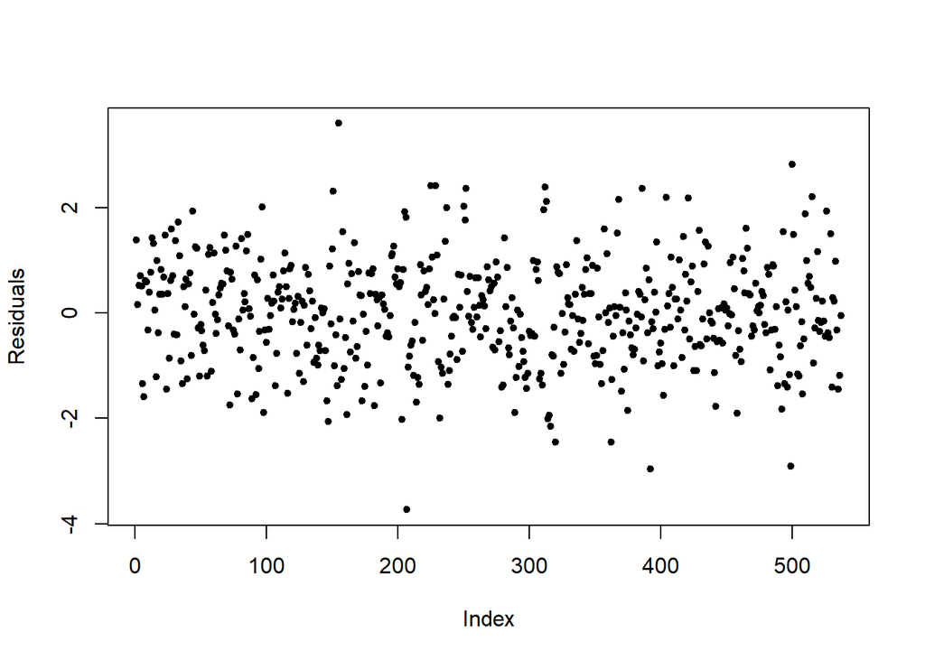

```r
plot(summary(m1.lmer)$residuals, ylab = "Residuals", pch = 20)
```

The plot shows that there is no structure in the cloud of dots but there there are some points with rather large residuals (these could be outliers). Next, we generate diagnostic plots that focus on the random effect structure.

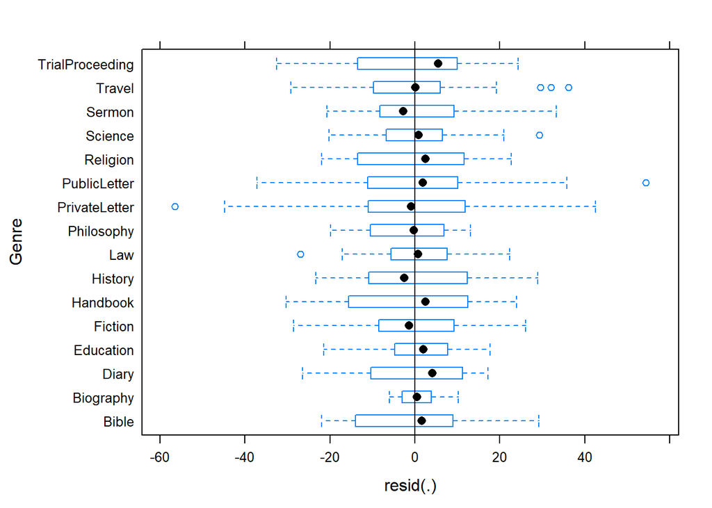

```r
plot(m1.lmer, Genre ~ resid(.), abline = 0 ) # generate diagnostic plots
```

The plot shows that there are some outliers (points outside the boxes) and that the variability within letters is greater than in other genres we therefore examine the genres in isolation standardized residuals versus fitted values (Pinheiro and Bates 2000, 175).

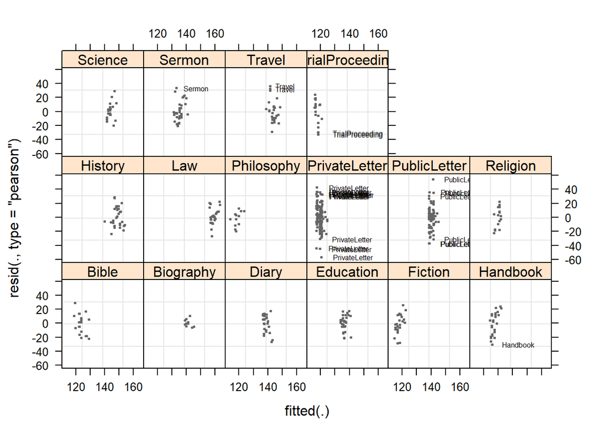

```r
plot(m1.lmer, resid(., type = "pearson") ~ fitted(.) | Genre, id = 0.05,
     adj = -0.3, pch = 20, col = "gray40", cex = .5)
```

The plot shows the standardized residuals (or Pearson’s residuals) versus fitted values and suggests that there are outliers in the data (the names elements in the plots). To check if these outliers are a cause for concern, we will now use a Levene’s test to check if the variance is distributed homogeneously (homoscedasticity) or whether the assumption of variance homogeneity is violated (due to the outliers).

> Note: the use of Levene’s test to check if the model is heteroscedastic is generally not recommended as it is too lax when dealing with few observations (because in such cases it does not have the power to identify heteroscedasticity) while it is too harsh when dealing with many observations (when heteroscedasticity typically is not a severe problem).

We use Levene’s test here merely to check if it substantiates the impressions we got from the visual inspection.

```r
# check homogeneity
leveneTest(lmmdata$Prepositions, lmmdata$Genre, center = mean)
```

```
## Levene's Test for Homogeneity of Variance (center = mean)
##        Df F value Pr(>F)
## group  15    1.74   0.04 *
##       521
## ---
## Signif. codes:  0 '***' 0.001 '**' 0.01 '*' 0.05 '.' 0.1 ' ' 1
```

The Levene’s test shows that the variance is distributed unevenly across genres which means that we do not simply continue but should either remove problematic data points (outliers) or use a weighing method.

> In this case, we will ignore this because this is just an example. If this were a real analysis, we would create a new model which uses weights to compensate for variance heterogeneiety.

We now create more diagnostic plots to check what other potential problems there are. What we wish to see in the diagnostic plots is a cloud of dots in the middle of the window without any structure. What we do not want to see is a funnel-shaped cloud because this indicates an increase of the errors/residuals with an increase of the predictor(s) (because this would indicate heteroscedasticity) (Pinheiro and Bates 2000, 182).

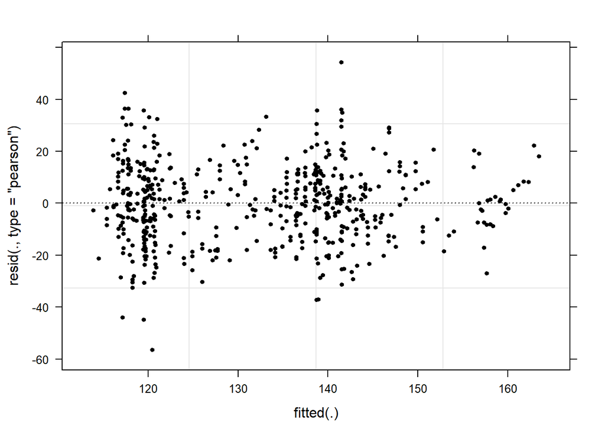

```r
# start plotting
par(mfrow = c(2, 2))           # display plots in 2 rows and 2 columns
plot(m1.lmer, pch = 20, col = "black", lty = "dotted"); par(mfrow = c(1, 1))
```

The lack of structure tells us that the model is *healthy* and does not suffer from heteroscedasticity. We will now create more diagnostic plots to find potential problems (Pinheiro and Bates 2000, 21).

We check the residuals of fitted values against observed values (Pinheiro and Bates 2000, 179). What we would like to see is a straight, upwards going line.

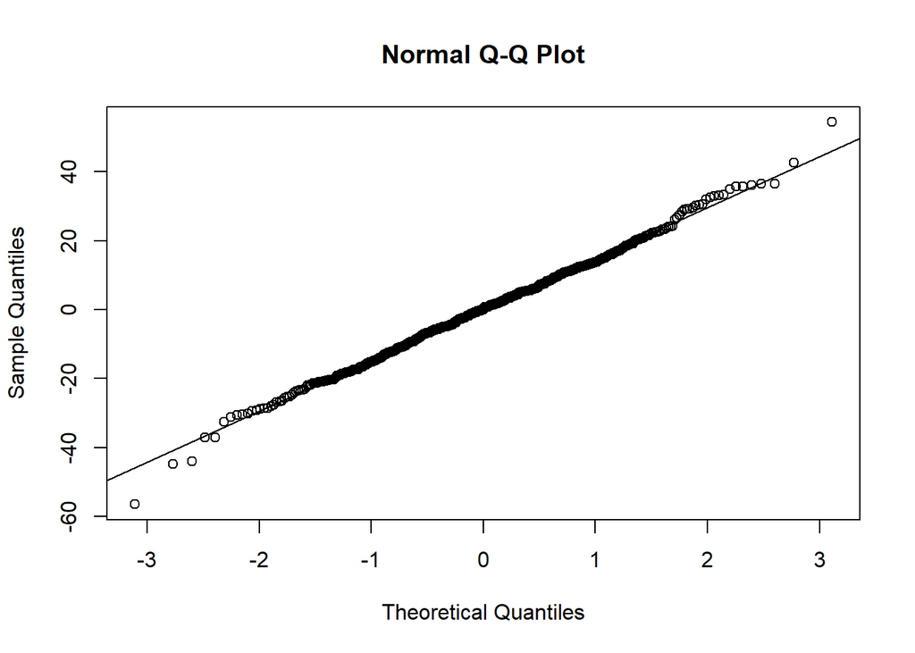

```r
qqnorm(resid(m1.lmer))
qqline(resid(m1.lmer))
```

Now, we inspect the observed responses versus the within-group fitted values (Pinheiro and Bates 2000, 178).

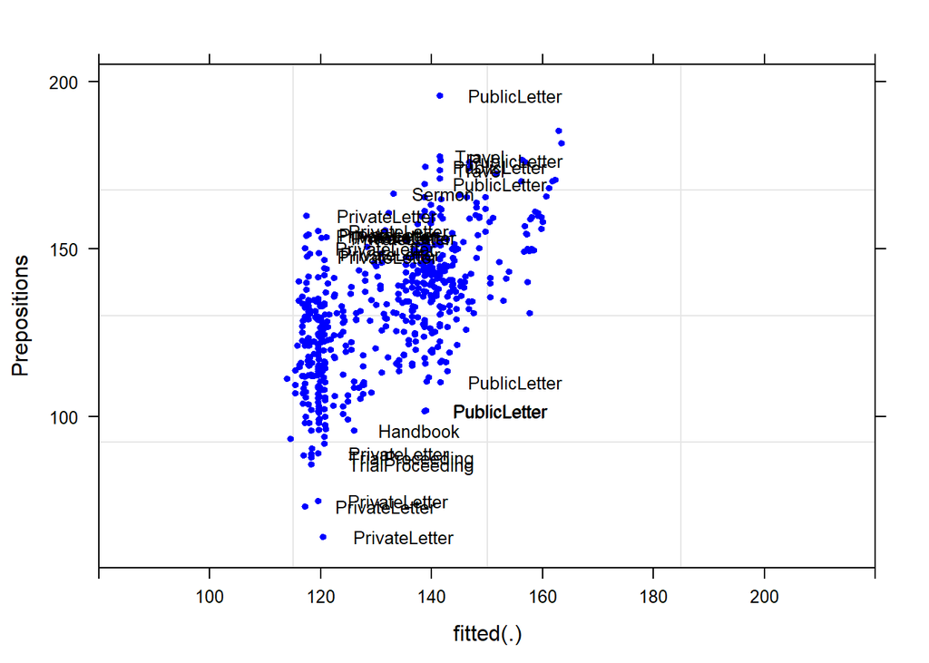

```r
# observed responses versus the within-group fitted values
plot(m1.lmer, Prepositions ~ fitted(.), id = 0.05, adj = -0.3,
     xlim = c(80, 220), cex = .8, pch = 20, col = "blue")
```

Although some data points are named, the plot does not show any structure, like a funnel, which would have been problematic.

### Model Summary

We will now summarize our results. We start by generating a summary table using the `tab_model` function from the `sjPlot` package.

```r
sjPlot::tab_model(m1.lmer)
```

|  | Prepositions |  |  |
| --- | --- | --- | --- |
| Predictors | Estimates | CI | p |
| (Intercept) | 133.89 | 127.52 – 140.25 | **<0.001** |
| Date | 0.02 | 0.01 – 0.03 | **0.003** |
| Random Effects |  |  |  |
| σ<sup>2</sup> | 228.76 |  |  |
| τ<sub>00</sub> <sub>Genre</sub> | 159.02 |  |  |
| ICC | 0.41 |  |  |
| N <sub>Genre</sub> | 16 |  |  |
| Observations | 537 |  |  |
| Marginal R<sup>2</sup> / Conditional R<sup>2</sup> | 0.012 / 0.417 |  |  |

The *marginal R<sup>2</sup>* (marginal coefficient of determination) represents the variance explained by the fixed effects while the *conditional R<sup>2</sup>* is interpreted as a variance explained by the entire model, including both fixed and random effects (Bartoń 2020).

The effects can be visualized using the `plot_model` function from the `sjPlot` package.

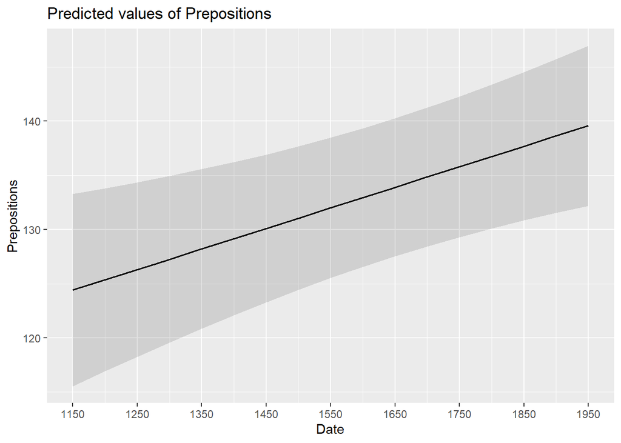

```r
sjPlot::plot_model(m1.lmer, type = "pred", terms = c("Date")) +
  # show uncentered date rather than centered date
  scale_x_continuous(name = "Date",
                     breaks = seq(-500, 300, 100),
                     labels = seq(1150, 1950, 100))
```

While we have already shown that the effect of Date is significant, it is small which means that the number of prepositions per text does not correlate very strongly with time. This suggests that other factors that are not included in the model also impact the frequency of prepositions (and probably more meaningfully, too).

## Mixed-Effects Binomial Logistic Regression

We now turn to an extension of binomial logistic regression: mixed-effects binomial logistic regression. As is the case with linear mixed-effects models logistic mixed effects models have the following advantages over simpler statistical tests:

- Mixed-effects models are multivariate, i.e. they test the effect of several predictors simultaneously while controlling for the effect of all other predictors.
- Mixed models allow to statistically incorporate within-speaker variability and are thus fit to model hierarchical or nested data structures. This applies if several observations are produced by an individual speaker, for instance.
- Mixed-models provide a wealth of diagnostic statistics which enables us to control e.g. multicollinearity (see [here](https://slcladal.github.io/,col.html) for an explanation of (multi-)collinearity) and to test whether conditions or requirements are violated (e.g. homogeneity of variance, etc.).

Major disadvantages of regression modeling are that they are prone to producing high $\beta$-errors (see Johnson 2009) and that they require rather large data sets.

### Introduction

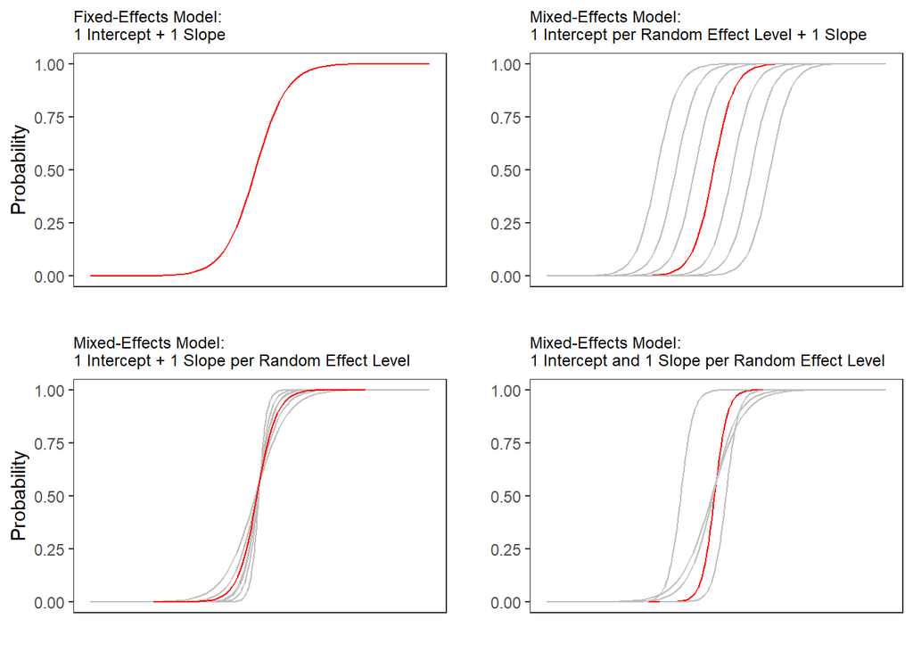

### Example: Discourse LIKE in Irish English

In this example we will investigate which factors correlate with the use of *final discourse like* (e.g. “*The weather is shite, like!*”) in Irish English. The data set represents speech units in a corpus that were coded for the speaker who uttered a given speech unit, the gender (Gender: Men versus Women) and age of that speaker (Age: Old versus Young), whether the interlocutors were of the same or a different gender (ConversationType: SameGender versus MixedGender), and whether another *final discourse like* had been used up to three speech units before (Priming: NoPrime versus Prime), whether or not the speech unit contained an *final discourse like* (SUFLike: 1 = yes, 0 = no. To begin with, we load the data and inspect the structure of the data set,

```r
# load data
mblrdata <- read.table("https://slcladal.github.io/data/mblrdata.txt",
                       comment.char = "",# data does not contain comments
                       quote = "",       # data does not contain quotes
                       sep = "\t",       # data is tab separated
                       header = T)       # data has column names
```

| ID | Gender | Age | ConversationType | Priming | SUFlike |
| --- | --- | --- | --- | --- | --- |
| S1A-061$C | Women | Young | MixedGender | NoPrime | 0 |
| S1A-023$B | Women | Young | MixedGender | NoPrime | 0 |
| S1A-054$A | Women | Young | SameGender | NoPrime | 0 |
| S1A-090$B | Women | Young | MixedGender | NoPrime | 0 |
| S1A-009$B | Women | Old | SameGender | Prime | 0 |
| S1A-085$E | Men | Young | MixedGender | Prime | 1 |
| S1A-003$C | Women | Young | MixedGender | NoPrime | 1 |
| S1A-084$C | Women | Young | SameGender | NoPrime | 0 |
| S1A-076$A | Women | Young | SameGender | NoPrime | 0 |
| S1A-083$D | Men | Old | MixedGender | NoPrime | 1 |

[output cut: 1990 more lines]

As all variables except for the dependent variable (`SUFlike`) are character strings, we factorize the independent variables.

```r
# def. variables to be factorized
vrs <- c("ID", "Age", "Gender", "ConversationType", "Priming")
# def. vector with variables
fctr <- which(colnames(mblrdata) %in% vrs)
# factorize variables
mblrdata[,fctr] <- lapply(mblrdata[,fctr], factor)
# relevel Age (Young = Reference)
mblrdata$Age <- relevel(mblrdata$Age, "Young")
# order data by ID
mblrdata <- mblrdata %>%
  dplyr::arrange(ID)
```

| ID | Gender | Age | ConversationType | Priming | SUFlike |
| --- | --- | --- | --- | --- | --- |
| S1A-001$A | Men | Old | SameGender | NoPrime | 0 |
| S1A-001$A | Men | Old | SameGender | NoPrime | 0 |
| S1A-001$A | Men | Old | SameGender | NoPrime | 0 |
| S1A-001$A | Men | Old | SameGender | NoPrime | 0 |
| S1A-001$A | Men | Old | SameGender | NoPrime | 0 |
| S1A-001$A | Men | Old | SameGender | NoPrime | 0 |
| S1A-001$A | Men | Old | SameGender | NoPrime | 0 |
| S1A-001$A | Men | Old | SameGender | NoPrime | 0 |
| S1A-001$B | Women | Old | MixedGender | NoPrime | 0 |
| S1A-001$B | Women | Old | MixedGender | NoPrime | 0 |

[output cut: 1990 more lines]

**Number of levels per random effect**

Before continuing, a few words about the minimum number of random effect levels and the minimum number of observations per random effect level are in order.

While many data points per random variable level increases statistical power and thus to more robust estimates of the random effects (Austin and Leckie 2018), it has been shown that small numbers of observations per random effect variable level do not cause serious bias and it does not negatively affect the estimates of the fixed-effects coefficients (Bell, Ferron, and Kromrey 2008; Clarke 2008; Clarke and Wheaton 2007; Maas and Hox 2005). The minimum number of observations per random effect variable level is therefore 1.

In simulation study, (Bell, Ferron, and Kromrey 2008) tested the impact of random variable levels with only a single observation ranging from 0 to 70 percent. As long as there was a relatively high number of random effect variable levels (500 or more), small numbers of observations had almost no impact on bias and Type 1 error control.

We now plot the data to inspect the relationships within the data set.

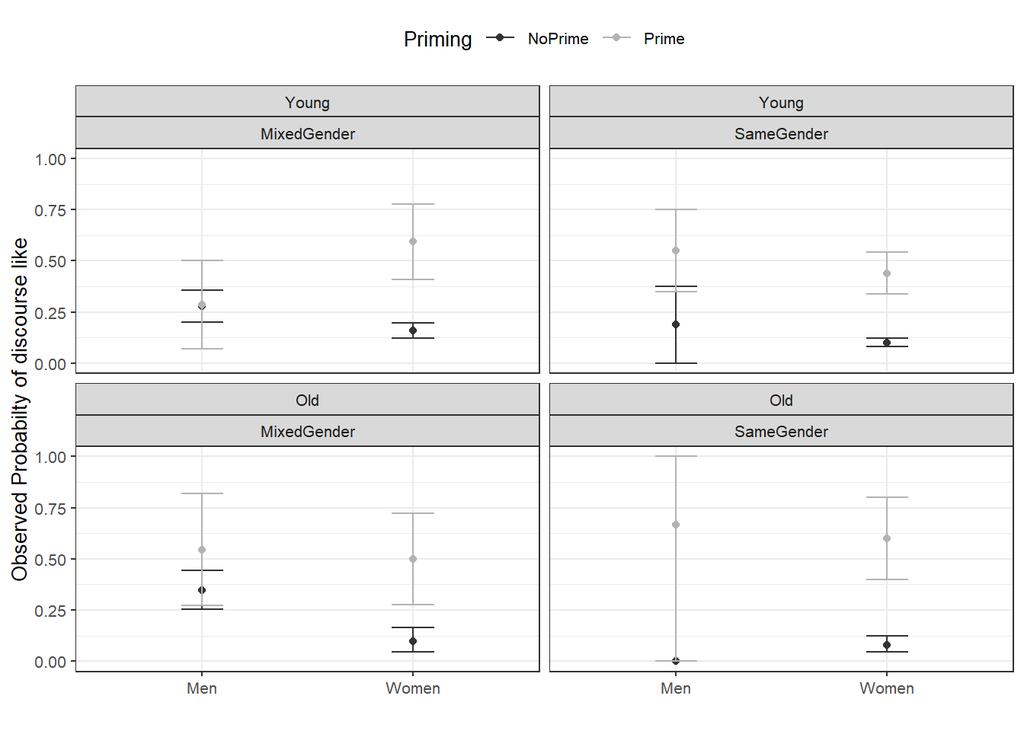

```r
ggplot(mblrdata, aes(Gender, SUFlike, color = Priming)) +
  facet_wrap(Age~ConversationType) +
  stat_summary(fun = mean, geom = "point") +
  stat_summary(fun.data = mean_cl_boot, geom = "errorbar", width = 0.2) +
  theme_bw(base_size = 10) +
  theme(legend.position = "top") +
  labs(x = "", y = "Observed Probabilty of discourse like") +
  scale_color_manual(values = c("gray20", "gray70"))
```

### Model Building

In a first step, we load packages and set the options. Here, we load the `rms` package, we set contrasts and we define a `datadist` object which stores information about the data set that we will need when we display the data and the visualize the effects in the model.

**Contrasts**

A short note on contrasts is warranted here. Contrasts define how the data is partitioned which affects how the model in interpreted. In this example, we use *treatment* contrast for categorical predictors (`contr.treatment`) and *polynomial* contrasts for numeric predictors (`contr.poly`). thus means that we compare levels of a categorical predictors against a reference variable (which in clinical trials would typically be the control group which receives no or a placebo treatment). This reference variable is the alphabetically first level by default but can be changed by using, e.g., `factor(x, ref = a)` or `relevel(x, ref = )`. The polynomial coding for numeric variables means that the effect of numeric variables is estimated for 0 by default (e.g. Date = 0 in the case of the linear model that we fit above).

There are other contrasts available, e.g. `contr.sum` (sum contrasts which compare the levels of a variable to the overall mean) which are akin to the typical ANOVA output. Also, contrasts can be specified manually which allows us to test specific hypotheses without the need of post-hoc tests (such as Turkey tests). A very(!) recommendable discussion and explanation of contrasts and how to specify them manually is provided by Gries (2021).

```r
library(rms)
# set options
options(contrasts  = c("contr.treatment", "contr.poly"))
mblrdata.dist <- datadist(mblrdata)
options(datadist = "mblrdata.dist")
```

In a next step, we generate fixed-effects minimal base-line models and a base-line mixed-model using the `glmer` function with a random intercept for ID (a `lmer` object of the final minimal adequate model will be created later).

```r
# baseline model glm
m0.glm = glm(SUFlike ~ 1, family = binomial, data = mblrdata)
# base-line mixed-model
m0.glmer = glmer(SUFlike ~ (1|ID), data = mblrdata, family = binomial)
```

### Testing the Random Effect

Now, we check if including the random effect is permitted by comparing the AICs from the glm to AIC from the glmer model. If the AIC of the `glmer` object is smaller than the AIC of the glm object, then this indicates that including random intercepts is justified.

```r
aic.glmer <- AIC(logLik(m0.glmer))
aic.glm <- AIC(logLik(m0.glm))
aic.glmer; aic.glm
```

```
## [1] 1828
```

```
## [1] 1838
```

The AIC of the glmer object is smaller which shows that including the random intercepts is justified.

### Model Fitting

The next step is to fit the model which means that we aim to find the “best” model, i.e. the minimal adequate model. In this case, we will use a manual step-wise step-up, forward elimination procedure.

### Excursion: Automatic Model Fitting and Why You Should Not Use It

**In this section, we will use a step-wise step-down procedure that uses decreases in AIC (*Akaike Information Criterion*) as the criterion to minimize the model in a step-wise manner.**

This procedure aims at finding the model with the lowest AIC values by evaluating - step-by-step - whether the removal of a predictor (term) leads to a lower AIC value.

We use this method here just so that you know it exists and how to implement it but you should rather avoid using automated model fitting. The reason for avoiding automated model fitting is that the algorithsm only checks if the AIC has decreased but not if the model is stable or reliable. Thus, automated model fitting has the problem that you can never be sure that the way that lead you to the final model is reliable and that all models were indeed stable. Imagine you want to climb down from a roof top and you have a ladder. The problem is that you do not know if and how many steps are broken. This is similar to using automated model fitting. In other sections, we will explore better methods to fit models (manual step-wise step-up and step-down procedures, for example).

The AIC is calculated using the equation below. The lower the AIC value, the better the balance between explained variance and the number of predictors. AIC values can and should only be compared for models that are fit on the same dataset with the same (number of) cases ($LL$ stands for LogLikelihood and $k$ represents the number of predictors in the model).

Akaike Information Criterion (AIC) = $-2LL + 2k$

An alternative to the AIC is the BIC (Bayesian Information Criterion). Both AIC and BIC penalize models for including variables in a model. The penalty of the BIC is bigger than the penalty of the AIC and it includes the number of cases in the model (*LL* stands for *logged likelihood* or *LogLikelihood*, *k* represents the number of predictors in the model (including the intercept), and *N* represents the number of cases in the model).

Bayesian Information Criterion (BIC) = $-2LL + 2k * log(N)$

Interactions are evaluated first and only if all insignificant interactions have been removed would the procedure start removing insignificant main effects (that are not part of significant interactions). Other model fitting procedures (forced entry, step-wise step up, hierarchical) are discussed during the implementation of other regression models. We cannot discuss all procedures here as model fitting is rather complex and a discussion of even the most common procedures would to lengthy and time consuming at this point. It is important to note though that there is not perfect model fitting procedure and automated approaches should be handled with care as they are likely to ignore violations of model parameters that can be detected during manual - but time consuming - model fitting procedures. As a general rule of thumb, it is advisable to fit models as carefully and deliberately as possible. We will now begin to fit the model.

Before we begin with the model fitting process we need to add ´control = glmerControl(optimizer = “bobyqa”)´ to avoid unnecessary failures to converge.

```r
m0.glmer <- glmer(SUFlike ~ 1+ (1|ID),
                  family = binomial,
                  data = mblrdata,
                  control=glmerControl(optimizer="bobyqa"))
```

During each step of the fitting procedure, we test whether certain assumptions on which the model relies are violated. To avoid *incomplete information* (a combination of variables does not occur in the data), we tabulate the variables we intend to include and make sure that all possible combinations are present in the data. Including variables although not all combinations are present in the data would lead to unreliable models that report (vastly) inaccurate results. A special case of incomplete information is *complete separation* which occurs if one predictor perfectly explains an outcome (in that case the incomplete information would be caused by a level of the dependent variable). In addition, we make sure that the VIFs do not exceed a maximum of 3 for main effects (Zuur, Ieno, and Elphick 2010) - Booth GD (1994) suggest that VIFs should ideally be lower than 3 for as higher values would indicate multicollinearity and thus that the model is unstable (see [here](https://slcladal.github.io/,col.html) for an explanation of (multi-)collinearity). The value of 3 should be taken with a pinch of salt because there is no clear consensus about what the maximum VIF for interactions should be or if it should be considered at all. The reason is that we would, of course, expect the VIFs to increase when we are dealing with interactions as the main effects that are part of the interaction are very likely to correlate with the interaction itself. However, if the VIFs are too high, then this will still cause the issues with the attribution of variance. The value of 3 was chosen based on recommendations in the standard literature on multicollinearity (Zuur et al. 2009; Neter, Wasserman, and Kutner 1990). Only once we have confirmed that the incomplete information, complete separation, and *multicollinearity* are not a major concern, we generate the more saturated model and test whether the inclusion of a predictor leads to a significant reduction in residual deviance. If the predictor explains a significant amount of variance, it is retained in the model while being disregarded in case it does not explain a sufficient quantity of variance.

```r
# add Priming
ifelse(min(ftable(mblrdata$Priming, mblrdata$SUFlike)) == 0,
       "incomplete information", "okay")
```

```
## [1] "okay"
```

```r
m1.glmer <- update(m0.glmer, .~.+Priming)
anova(m1.glmer, m0.glmer, test = "Chi")
```

```
## Data: mblrdata
## Models:
## m0.glmer: SUFlike ~ 1 + (1 | ID)
## m1.glmer: SUFlike ~ (1 | ID) + Priming
##          npar  AIC  BIC logLik deviance Chisq Df          Pr(>Chisq)
## m0.glmer    2 1828 1840   -912     1824
## m1.glmer    3 1703 1720   -848     1697   128  1 <0.0000000000000002 ***
## ---
## Signif. codes:  0 '***' 0.001 '**' 0.01 '*' 0.05 '.' 0.1 ' ' 1
```

Since the tests do not show problems relating to incomplete information, because including *Priming* significantly improves the model fit (decrease in AIC and BIC values), and since it correlates significantly with our dependent variable, we include *Priming* into our model.

```r
# add Age
ifelse(min(ftable(mblrdata$Age, mblrdata$SUFlike)) == 0,
       "incomplete information", "okay")
```

```
## [1] "okay"
```

```r
m2.glmer <- update(m1.glmer, .~.+ Age)
ifelse(max(car::vif(m2.glmer)) <= 3,  "VIFs okay", "VIFs unacceptable")
```

```
## [1] "VIFs okay"
```

```r
anova(m2.glmer, m1.glmer, test = "Chi")
```

```
## Data: mblrdata
## Models:
## m1.glmer: SUFlike ~ (1 | ID) + Priming
## m2.glmer: SUFlike ~ (1 | ID) + Priming + Age
##          npar  AIC  BIC logLik deviance Chisq Df Pr(>Chisq)
## m1.glmer    3 1703 1720   -848     1697
## m2.glmer    4 1704 1727   -848     1696  0.56  1       0.45
```

```r
Anova(m2.glmer, test = "Chi")
```

```
## Analysis of Deviance Table (Type II Wald chisquare tests)
##
## Response: SUFlike
##          Chisq Df          Pr(>Chisq)
## Priming 129.51  1 <0.0000000000000002 ***
## Age       0.57  1                0.45
## ---
## Signif. codes:  0 '***' 0.001 '**' 0.01 '*' 0.05 '.' 0.1 ' ' 1
```

The ANOVAs show that *Age* is not significant and the first ANOVA also shows that the BIC has increased which indicates that *Age* does not decrease variance. In such cases, the variable should not be included.

However, if the second ANOVA would report *Age* as being marginally significant, a case could be made for including it but it would be better to change the ordering in which predictors are added to the model. This is, however, just a theoretical issue here as *Age* is clearly not significant.

```r
# add Gender
ifelse(min(ftable(mblrdata$Gender, mblrdata$SUFlike)) == 0,
       "incomplete information", "okay")
```

```
## [1] "okay"
```

```r
m3.glmer <- update(m1.glmer, .~.+Gender)
ifelse(max(car::vif(m3.glmer)) <= 3,  "VIFs okay", "VIFs unacceptable")
```

```
## [1] "VIFs okay"
```

```r
anova(m3.glmer, m1.glmer, test = "Chi")
```

```
## Data: mblrdata
## Models:
## m1.glmer: SUFlike ~ (1 | ID) + Priming
## m3.glmer: SUFlike ~ (1 | ID) + Priming + Gender
##          npar  AIC  BIC logLik deviance Chisq Df Pr(>Chisq)
## m1.glmer    3 1703 1720   -848     1697
## m3.glmer    4 1679 1702   -836     1671  25.4  1 0.00000047 ***
## ---
## Signif. codes:  0 '***' 0.001 '**' 0.01 '*' 0.05 '.' 0.1 ' ' 1
```

```r
Anova(m3.glmer, test = "Chi")
```

```
## Analysis of Deviance Table (Type II Wald chisquare tests)
##
## Response: SUFlike
##         Chisq Df           Pr(>Chisq)
## Priming 124.4  1 < 0.0000000000000002 ***
## Gender   28.6  1           0.00000009 ***
## ---
## Signif. codes:  0 '***' 0.001 '**' 0.01 '*' 0.05 '.' 0.1 ' ' 1
```

*Gender* is significant and will therefore be included as a predictor (you can also observe that including Gender has substantially decreased both AIC and BIC).

```r
# add ConversationType
ifelse(min(ftable(mblrdata$ConversationType, mblrdata$SUFlike)) == 0,
       "incomplete information", "okay")
```

```
## [1] "okay"
```

```r
m4.glmer <- update(m3.glmer, .~.+ConversationType)
ifelse(max(car::vif(m4.glmer)) <= 3,  "VIFs okay", "VIFs unacceptable")
```

```
## [1] "VIFs okay"
```

```r
anova(m4.glmer, m3.glmer, test = "Chi")
```

```
## Data: mblrdata
## Models:
## m3.glmer: SUFlike ~ (1 | ID) + Priming + Gender
## m4.glmer: SUFlike ~ (1 | ID) + Priming + Gender + ConversationType
##          npar  AIC  BIC logLik deviance Chisq Df Pr(>Chisq)
## m3.glmer    4 1679 1702   -836     1671
## m4.glmer    5 1669 1697   -829     1659  12.8  1    0.00034 ***
## ---
## Signif. codes:  0 '***' 0.001 '**' 0.01 '*' 0.05 '.' 0.1 ' ' 1
```

```r
Anova(m4.glmer, test = "Chi")
```

```
## Analysis of Deviance Table (Type II Wald chisquare tests)
##
## Response: SUFlike
##                  Chisq Df           Pr(>Chisq)
## Priming          130.7  1 < 0.0000000000000002 ***
## Gender            13.4  1              0.00025 ***
## ConversationType  13.0  1              0.00031 ***
## ---
## Signif. codes:  0 '***' 0.001 '**' 0.01 '*' 0.05 '.' 0.1 ' ' 1
```

*ConversationType* improves model fit (AIC and BIC decrease and it is reported as being significant) and will, therefore, be included in the model.

```r
# add Priming*Age
ifelse(min(ftable(mblrdata$Priming, mblrdata$Age, mblrdata$SUFlike)) == 0,
       "incomplete information", "okay")
```

```
## [1] "okay"
```

```r
m5.glmer <- update(m4.glmer, .~.+Priming*Age)
ifelse(max(car::vif(m5.glmer)) <= 3,  "VIFs okay", "WARNING: high VIFs!")
```

```
## [1] "VIFs okay"
```

```r
anova(m5.glmer, m4.glmer, test = "Chi")
```

```
## Data: mblrdata
## Models:
## m4.glmer: SUFlike ~ (1 | ID) + Priming + Gender + ConversationType
## m5.glmer: SUFlike ~ (1 | ID) + Priming + Gender + ConversationType + Age +
## m5.glmer:     Priming:Age
##          npar  AIC  BIC logLik deviance Chisq Df Pr(>Chisq)
## m4.glmer    5 1669 1697   -829     1659
## m5.glmer    7 1672 1711   -829     1658  0.98  2       0.61
```

The interaction between *Priming* and *Age* is not significant and we thus not be included.

```r
# add Priming*Gender
ifelse(min(ftable(mblrdata$Priming, mblrdata$Gender, mblrdata$SUFlike)) == 0,
       "incomplete information", "okay")
```

```
## [1] "okay"
```

```r
m6.glmer <- update(m4.glmer, .~.+Priming*Gender)
ifelse(max(car::vif(m6.glmer)) <= 3,  "VIFs okay", "WARNING: high VIFs!")
```

```
## [1] "WARNING: high VIFs!"
```

We get the warning that the VIFs are high (>= 3) which means that the model suffers from (multi-)collinearity. We thus check the VIFs to determine how to proceed. If the VIFs are > 10, then we definitely cannot use the model as the multicollinearity is excessive.

```r
car::vif(m6.glmer)
```

```
##          Priming           Gender ConversationType   Priming:Gender
##            4.357            1.433            1.203            4.583
```

The VIFs are below 5 which is not good (VIFs of 5 mean “that column in the model matrix is explainable from the others with an R<sup>2</sup> of 0.8” (Gries 2021)) but it is still arguably acceptable and we will thus check if including the interaction between *Priming* and *Gender* significantly improved model fit.

```r
anova(m6.glmer, m4.glmer, test = "Chi")
```

```
## Data: mblrdata
## Models:
## m4.glmer: SUFlike ~ (1 | ID) + Priming + Gender + ConversationType
## m6.glmer: SUFlike ~ (1 | ID) + Priming + Gender + ConversationType + Priming:Gender
##          npar  AIC  BIC logLik deviance Chisq Df Pr(>Chisq)
## m4.glmer    5 1669 1697   -829     1659
## m6.glmer    6 1663 1697   -826     1651  7.42  1     0.0065 **
## ---
## Signif. codes:  0 '***' 0.001 '**' 0.01 '*' 0.05 '.' 0.1 ' ' 1
```

```r
Anova(m6.glmer, test = "Chi")
```

```
## Analysis of Deviance Table (Type II Wald chisquare tests)
##
## Response: SUFlike
##                   Chisq Df           Pr(>Chisq)
## Priming          131.96  1 < 0.0000000000000002 ***
## Gender            13.58  1              0.00023 ***
## ConversationType  10.71  1              0.00107 **
## Priming:Gender     7.45  1              0.00633 **
## ---
## Signif. codes:  0 '***' 0.001 '**' 0.01 '*' 0.05 '.' 0.1 ' ' 1
```

```r
# add Priming*ConversationType
ifelse(min(ftable(mblrdata$Priming, mblrdata$ConversationType, mblrdata$SUFlike)) == 0,
       "incomplete information", "okay")
```

```
## [1] "okay"
```

```r
m7.glmer <- update(m6.glmer, .~.+Priming*ConversationType)
ifelse(max(car::vif(m7.glmer)) <= 3,  "VIFs okay", "WARNING: high VIFs!")
```

```
## [1] "WARNING: high VIFs!"
```

When including the interaction between *Priming* and *ConversationType* we get a warning that there are high VIFs (multicollinearity) so we inspect the VIFs in more detail.

```r
# check VIFs
car::vif(m7.glmer)
```

```
##                  Priming                   Gender         ConversationType
##                    5.106                    1.493                    1.492
##           Priming:Gender Priming:ConversationType
##                    4.929                    3.410
```

The VIF of *Priming* is above 5 so we would normally continue without checking if including the interaction between *Priming* and *ConversationType* leads to a significant improvement in model fit. However, given that this is just a practical example, we check if including this interaction significantly improves model fit.

```r
anova(m7.glmer, m6.glmer, test = "Chi")
```

```
## Data: mblrdata
## Models:
## m6.glmer: SUFlike ~ (1 | ID) + Priming + Gender + ConversationType + Priming:Gender
## m7.glmer: SUFlike ~ (1 | ID) + Priming + Gender + ConversationType + Priming:Gender +
## m7.glmer:     Priming:ConversationType
##          npar  AIC  BIC logLik deviance Chisq Df Pr(>Chisq)
## m6.glmer    6 1663 1697   -826     1651
## m7.glmer    7 1663 1702   -825     1649  2.03  1       0.15
```

```r
# add Age*Gender
ifelse(min(ftable(mblrdata$Age, mblrdata$Gender, mblrdata$SUFlike)) == 0,
       "incomplete information", "okay")
```

```
## [1] "okay"
```

```r
m8.glmer <- update(m6.glmer, .~.+Age*Gender)
ifelse(max(car::vif(m8.glmer)) <= 3,  "VIFs okay", "WARNING: high VIFs!")
```

```
## [1] "WARNING: high VIFs!"
```

When including the interaction between *Age* and *Gender* we get a warning that there are high VIFs (multicollinearity) so we inspect the VIFs in more detail.

```r
# check VIFs
car::vif(m8.glmer)
```

```
##          Priming           Gender ConversationType              Age
##            4.462            2.142            1.206            3.252
##   Priming:Gender       Gender:Age
##            4.668            3.213
```

The VIFs are all below 5 so we test if including the interaction between *Gender* and *Age* significantly improves model fit.

```r
anova(m8.glmer, m6.glmer, test = "Chi")
```

```
## Data: mblrdata
## Models:
## m6.glmer: SUFlike ~ (1 | ID) + Priming + Gender + ConversationType + Priming:Gender
## m8.glmer: SUFlike ~ (1 | ID) + Priming + Gender + ConversationType + Age +
## m8.glmer:     Priming:Gender + Gender:Age
##          npar  AIC  BIC logLik deviance Chisq Df Pr(>Chisq)
## m6.glmer    6 1663 1697   -826     1651
## m8.glmer    8 1666 1710   -825     1650  1.53  2       0.47
```

The interaction between *Age* and *Gender* is not significant and will thus continue without it.

```r
# add Age*ConversationType
ifelse(min(ftable(mblrdata$Age, mblrdata$ConversationType, mblrdata$SUFlike)) == 0,
       "incomplete information", "okay")
```

```
## [1] "okay"
```

```r
m9.glmer <- update(m6.glmer, .~.+Age*ConversationType)
ifelse(max(car::vif(m9.glmer)) <= 3,  "VIFs okay", "WARNING: high VIFs!")
```

```
## [1] "WARNING: high VIFs!"
```

When including the interaction between *Age* and *ConversationType* we get a warning that there are high VIFs (multicollinearity) so we inspect the VIFs in more detail.

```r
# check VIFs
car::vif(m9.glmer)
```

```
##              Priming               Gender     ConversationType
##                4.378                1.507                1.515
##                  Age       Priming:Gender ConversationType:Age
##                1.969                4.614                2.059
```

The VIFs are all below 5 so we test if including the interaction between *ConversationType* and *Age* significantly improves model fit.

```r
anova(m9.glmer, m6.glmer, test = "Chi")
```

```
## Data: mblrdata
## Models:
## m6.glmer: SUFlike ~ (1 | ID) + Priming + Gender + ConversationType + Priming:Gender
## m9.glmer: SUFlike ~ (1 | ID) + Priming + Gender + ConversationType + Age +
## m9.glmer:     Priming:Gender + ConversationType:Age
##          npar  AIC  BIC logLik deviance Chisq Df Pr(>Chisq)
## m6.glmer    6 1663 1697   -826     1651
## m9.glmer    8 1666 1711   -825     1650   0.9  2       0.64
```

The interaction between *Age* and *ConversationType* is insignificant and does not improve model fit (AIC and BIC reduction). It will therefore not be included in the model.

```r
# add Gender*ConversationType
ifelse(min(ftable(mblrdata$Gender, mblrdata$ConversationType, mblrdata$SUFlike)) == 0,
       "incomplete information", "okay")
```

```
## [1] "okay"
```

```r
m10.glmer <- update(m6.glmer, .~.+Gender*ConversationType)
ifelse(max(car::vif(m10.glmer)) <= 3,  "VIFs okay", "WARNING: high VIFs!")
```

```
## [1] "WARNING: high VIFs!"
```

When including the interaction between *Gender* and *ConversationType* we get a warning that there are high VIFs (multicollinearity) so we inspect the VIFs in more detail.

```r
# check VIFs
car::vif(m10.glmer)
```

```
##                 Priming                  Gender        ConversationType
##                   4.962                   1.733                   7.766
##          Priming:Gender Gender:ConversationType
##                   5.119                   9.251
```

The highest VIF is almost 10 (9.251) which is why the interaction between *Gender* and *ConversationType* will not be included in the model.

```r
# add Priming*Age*Gender
ifelse(min(ftable(mblrdata$Priming,mblrdata$Age, mblrdata$Gender, mblrdata$SUFlike)) == 0,
       "incomplete information", "okay")
```

```
## [1] "okay"
```

```r
m11.glmer <- update(m6.glmer, .~.+Priming*Age*Gender)
ifelse(max(car::vif(m11.glmer)) <= 3,  "VIFs okay", "WARNING: high VIFs!")
```

```
## [1] "WARNING: high VIFs!"
```

When including the interaction between *Priming*, *Age*, and *Gender* we get a warning that there are high VIFs (multicollinearity) so we inspect the VIFs in more detail.

```r
# check VIFs
car::vif(m11.glmer)
```

```
##            Priming             Gender   ConversationType                Age
##              6.573              2.284              1.223              3.660
##     Priming:Gender        Priming:Age         Gender:Age Priming:Gender:Age
##              6.659              5.852              3.758              5.979
```

There are several VIFs with values greater than 5 and we will thus continue without including the interaction between *Priming*, *Age*, and *Gender* into the model.

```r
# add Priming*Age*ConversationType
ifelse(min(ftable(mblrdata$Priming,mblrdata$Age, mblrdata$ConversationType, mblrdata$SUFlike)) == 0,
       "incomplete information", "okay")
```

```
## [1] "okay"
```

```r
m12.glmer <- update(m6.glmer, .~.+Priming*Age*ConversationType)
ifelse(max(car::vif(m12.glmer)) <= 3,  "VIFs okay", "WARNING: high VIFs!")
```

```
## [1] "WARNING: high VIFs!"
```

```r
# check VIFs
car::vif(m12.glmer)
```

```
##                      Priming                       Gender
##                        7.147                        1.611
##             ConversationType                          Age
##                        1.832                        2.202
##               Priming:Gender                  Priming:Age
##                        4.993                        3.332
##     Priming:ConversationType         ConversationType:Age
##                        4.874                        2.383
## Priming:ConversationType:Age
##                        2.999
```

```r
# add Priming*Gender*ConversationType
ifelse(min(ftable(mblrdata$Priming,mblrdata$Gender, mblrdata$ConversationType, mblrdata$SUFlike)) == 0,
       "incomplete information", "okay")
```

```
## [1] "okay"
```

```r
m13.glmer <- update(m6.glmer, .~.+Priming*Gender*ConversationType)
ifelse(max(car::vif(m13.glmer)) <= 3,  "VIFs okay", "WARNING: high VIFs!")
```

```
## [1] "WARNING: high VIFs!"
```

```r
car::vif(m13.glmer)
```

```
##                         Priming                          Gender
##                           7.696                           1.812
##                ConversationType                  Priming:Gender
##                          21.932                          10.014
##        Priming:ConversationType         Gender:ConversationType
##                          21.622                          23.869
## Priming:Gender:ConversationType
##                          22.669
```

The VIFs are excessive with a maximum value is 23.8693 which shows an unacceptable degree of multicollinearity so that we abort and move on the next model.

```r
# add Age*Gender*ConversationType
ifelse(min(ftable(mblrdata$Age,mblrdata$Gender, mblrdata$ConversationType, mblrdata$SUFlike)) == 0,
       "incomplete information", "okay")
```

```
## [1] "okay"
```

```r
m14.glmer <- update(m6.glmer, .~.+Age*Gender*ConversationType)
ifelse(max(car::vif(m14.glmer)) <= 3,  "VIFs okay", "WARNING: high VIFs!")
```

```
## [1] "WARNING: high VIFs!"
```

When including the interaction between *Age*, *Gender*, *ConversationType*, we get a warning that there are high VIFs (multicollinearity) so we inspect the VIFs in more detail.

```r
car::vif(m14.glmer)
```

```
##                     Priming                      Gender
##                       5.333                       2.601
##            ConversationType                         Age
##                      11.947                       3.801
##              Priming:Gender                  Gender:Age
##                       5.455                       5.662
##        ConversationType:Age     Gender:ConversationType
##                      16.993                      13.812
## Gender:ConversationType:Age
##                      19.084
```

Again, the VIFs are excessive with a maximum value of 19.0842 which shows an unacceptable degree of multicollinearity so that we abort and move on the next model.

```r
# add Priming*Age*Gender*ConversationType
ifelse(min(ftable(mblrdata$Priming,mblrdata$Age,mblrdata$Gender, mblrdata$ConversationType, mblrdata$SUFlike)) == 0,
       "incomplete information", "okay")
```

```
## [1] "incomplete information"
```

The model suffers from incomplete information! As this was the last possible model, we have found our final minimal adequate model in m6.glmer.

In a next step, we create an overview of model comparisons which serves as a summary for the model fitting process and provides AIC, BIC, and $\chi$<sup>2</sup> values.

```r
source("https://slcladal.github.io/rscripts/ModelFittingSummarySWSU.r")
# comparisons of glmer objects
m1.m0 <- anova(m1.glmer, m0.glmer, test = "Chi")
m2.m1 <- anova(m2.glmer, m1.glmer, test = "Chi")
m3.m1 <- anova(m3.glmer, m1.glmer, test = "Chi")
m4.m3 <- anova(m4.glmer, m3.glmer, test = "Chi")
m5.m4 <- anova(m5.glmer, m4.glmer, test = "Chi")
m6.m4 <- anova(m6.glmer, m4.glmer, test = "Chi")
m7.m6 <- anova(m7.glmer, m6.glmer, test = "Chi")
m8.m6 <- anova(m8.glmer, m6.glmer, test = "Chi")
m9.m6 <- anova(m9.glmer, m6.glmer, test = "Chi")
# create a list of the model comparisons
mdlcmp <- list(m1.m0, m2.m1, m3.m1, m4.m3, m5.m4, m6.m4, m7.m6, m8.m6, m9.m6)
# summary table for model fitting
mdlft <- mdl.fttng.swsu(mdlcmp)
mdlft <- mdlft[,-2]
```

| Model | Term Added | Compared to… | DF | AIC | BIC | LogLikelihood | Residual Deviance | X2 | X2DF | p-value | Significance |
| --- | --- | --- | --- | --- | --- | --- | --- | --- | --- | --- | --- |
| m1.glmer | 1+Priming | m0.glmer | 3 | 1702.77 | 1719.58 | -848.39 | 1696.77 | 127.72 | 1 | 0 | p < .001*** |
| m2.glmer | Age | m1.glmer | 4 | 1704.21 | 1726.61 | -848.11 | 1696.21 | 0.56 | 1 | 0.45323 | n.s. |
| m3.glmer | Gender | m1.glmer | 4 | 1679.4 | 1701.8 | -835.7 | 1671.4 | 25.38 | 1 | 0 | p < .001*** |
| m4.glmer | ConversationType | m3.glmer | 5 | 1668.58 | 1696.59 | -829.29 | 1658.58 | 12.81 | 1 | 0.00034 | p < .001*** |
| m5.glmer | Age+Priming:Age | m4.glmer | 7 | 1671.6 | 1710.81 | -828.8 | 1657.6 | 0.98 | 2 | 0.61134 | n.s. |
| m6.glmer | Priming:Gender | m4.glmer | 6 | 1663.16 | 1696.77 | -825.58 | 1651.16 | 7.42 | 1 | 0.00645 | p < .01 ** |
| m7.glmer | Priming:ConversationType | m6.glmer | 7 | 1663.13 | 1702.34 | -824.57 | 1649.13 | 2.03 | 1 | 0.15427 | n.s. |
| m8.glmer | Age+Gender:Age | m6.glmer | 8 | 1665.63 | 1710.44 | -824.82 | 1649.63 | 1.53 | 2 | 0.46535 | n.s. |
| m9.glmer | Age+ConversationType:Age | m6.glmer | 8 | 1666.26 | 1711.07 | -825.13 | 1650.26 | 0.9 | 2 | 0.63689 | n.s. |

We now rename our final minimal adequate model, test whether it performs significantly better than the minimal base-line model, and print the regression summary.

```r
# rename final minimal adequate model
mlr.glmer <- m6.glmer
# final model better than base-line model
sigfit <- anova(mlr.glmer, m0.glmer, test = "Chi")
# inspect
sigfit
```

```
## Data: mblrdata
## Models:
## m0.glmer: SUFlike ~ 1 + (1 | ID)
## mlr.glmer: SUFlike ~ (1 | ID) + Priming + Gender + ConversationType + Priming:Gender
##           npar  AIC  BIC logLik deviance Chisq Df          Pr(>Chisq)
## m0.glmer     2 1828 1840   -912     1824
## mlr.glmer    6 1663 1697   -826     1651   173  4 <0.0000000000000002 ***
## ---
## Signif. codes:  0 '***' 0.001 '**' 0.01 '*' 0.05 '.' 0.1 ' ' 1
```

```r
# inspect final minimal adequate model
print(mlr.glmer, corr = F)
```

```
## Generalized linear mixed model fit by maximum likelihood (Laplace
##   Approximation) [glmerMod]
##  Family: binomial  ( logit )
## Formula:
## SUFlike ~ (1 | ID) + Priming + Gender + ConversationType + Priming:Gender
##    Data: mblrdata
##      AIC      BIC   logLik deviance df.resid
##   1663.2   1696.8   -825.6   1651.2     1994
## Random effects:
##  Groups Name        Std.Dev.
##  ID     (Intercept) 0.292
## Number of obs: 2000, groups:  ID, 208
## Fixed Effects:
##                (Intercept)                PrimingPrime
##                     -0.921                       1.060
##                GenderWomen  ConversationTypeSameGender
##                     -0.868                      -0.492
##   PrimingPrime:GenderWomen
##                      1.036
```

Let’s go over the output. The first part tells us what kind of model was fit to the data (a *generalized linear mixed model*), that it was fit by *maximum likelihood* (rather than restricted maximum likelihood), and that the model linked the predictors to the response by fitting the model to the logits of the response variable (rather than the response variable itself).

The output then provides use with the model formula and the data to which the model was fit. Next, we get model fit parameters (the AIC, the BIC, the logLik (logged Likelihood), the residual deviance, and the residual degrees of freedom). All of these measures are uninformative by themselves but they are meaningful when comparing this model to another model that was fit to the same data as better model fit would mean lower values. Thus, if we compared two outputs of model that were fit to the same data, the model with the lower AIC, BIC, logLik, and residual deviance would be the *better* model.

Next, the model reports the standard deviation of the random effect which is used later to check how much variance is explained by the random effect structure (in the tabulated model report), the number of observation that the model is fit to, and the number of groups of the random effect.

Then, the output reports the estimates of the predictors which represent the logged odds - values smaller than 1 indicate a negative correlation while values above 1 indicate a positive correlation with the response variable. These logged odds can be transformed into probabilities using the `plogit` function. the probability of discourse *like* appearing in a primed speech unit would thus be the probability of the intercept + the probability of `PrimingPrime`:

```r
# calculate probability
plogis(-0.921+1.060)
```

```
## [1] 0.5347
```

Hence, the probability of discourse *like* being used in a primed speech unit is 0.5347. Commonly, however, the effects in generalized linear mixed effects binomial logistic regressions are reported not as probabilities but as Odds Ratios which tell use how many times more (or less) likely it is that a response occurs given a certain variable level. To transform the logged odds into Odds Ratios, we exponentiate the estimates. Applied to the present case, we would could say that discourse like is `exp(1.060)` or 2.8864 times more likely to occur in a primed context compared to a non-primed context.

To extract the effect sizes of the significant fixed effects, we compare the model with that effect to a model without that effect. This can be problematic when checking the effect of main effects that are involved in significant interactions though (Field, Miles, and Field 2012, 622).

```r
# effect of ConversationType
ef_conv <- anova(m4.glmer, m3.glmer, test = "Chi")
# inspect
ef_conv
```

```
## Data: mblrdata
## Models:
## m3.glmer: SUFlike ~ (1 | ID) + Priming + Gender
## m4.glmer: SUFlike ~ (1 | ID) + Priming + Gender + ConversationType
##          npar  AIC  BIC logLik deviance Chisq Df Pr(>Chisq)
## m3.glmer    4 1679 1702   -836     1671
## m4.glmer    5 1669 1697   -829     1659  12.8  1    0.00034 ***
## ---
## Signif. codes:  0 '***' 0.001 '**' 0.01 '*' 0.05 '.' 0.1 ' ' 1
```

```r
# effect of Priming:Gender
ef_prigen <- anova(m6.glmer, m4.glmer, test = "Chi")
# inspect
ef_prigen
```

```
## Data: mblrdata
## Models:
## m4.glmer: SUFlike ~ (1 | ID) + Priming + Gender + ConversationType
## m6.glmer: SUFlike ~ (1 | ID) + Priming + Gender + ConversationType + Priming:Gender
##          npar  AIC  BIC logLik deviance Chisq Df Pr(>Chisq)
## m4.glmer    5 1669 1697   -829     1659
## m6.glmer    6 1663 1697   -826     1651  7.42  1     0.0065 **
## ---
## Signif. codes:  0 '***' 0.001 '**' 0.01 '*' 0.05 '.' 0.1 ' ' 1
```

**Post-Hoc Tests**

If you want to test is levels of a categorical predictor differ significantly with respect to their effect on the response variable, you can use so-called post-hoc test. While it is better to specify contrasts and thus avoid repeated testing (as this increases the probability of $\alpha$-errors), post-hoc tests have the advantage that they are easily implemented and avoid potential problems when specifying contrasts manually (which cane be hard - especially when one does not do this regularly). The code below shows how such a post-hoc test could be implemented. However, in the present case, we do not need post-hoc tests because none of our categorical predictors has more than two levels.

```r
# load package
library (multcomp)
# perform post-hoc test
summary(glht(model, mcp(predictor="Tukey")))
# example
summary(glht(m5.glmer, mcp(Ethnicity="Tukey")))
```

### Visualizing Effects

As we will see the effects in the final summary, we visualize the effects here by showing the probability of discourse *like* based on the predicted values.

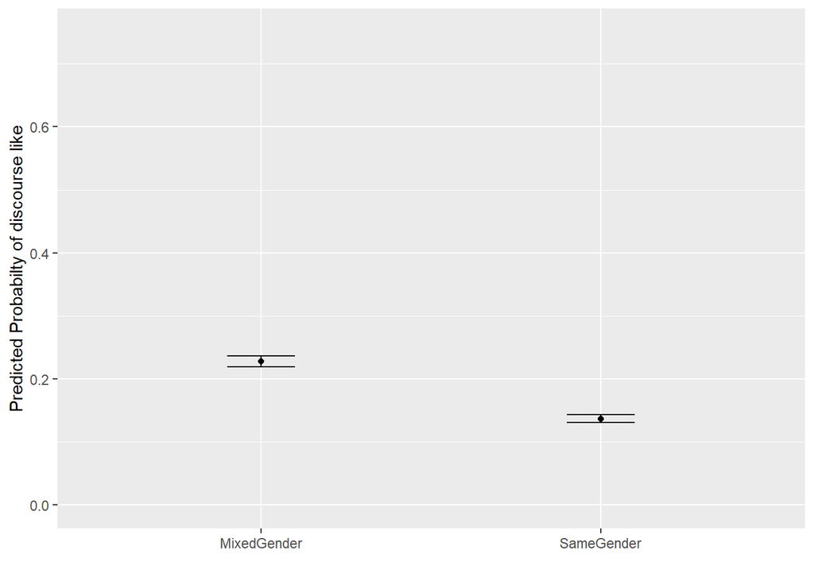

```r
# extract predicted values
mblrdata$Predicted <- predict(m6.glmer, mblrdata, type = "response")
# plot
ggplot(mblrdata, aes(ConversationType, Predicted)) +
  stat_summary(fun = mean, geom = "point") +
  stat_summary(fun.data = mean_cl_boot, geom = "errorbar", width = 0.2) +
  theme_set(theme_bw(base_size = 10)) +
  theme(legend.position = "top") +
    ylim(0, .75) +
  labs(x = "", y = "Predicted Probabilty of discourse like") +
  scale_color_manual(values = c("gray20", "gray70"))
```

A proper visualization of the marginal effects can be extracted using the `sjPlot` package.

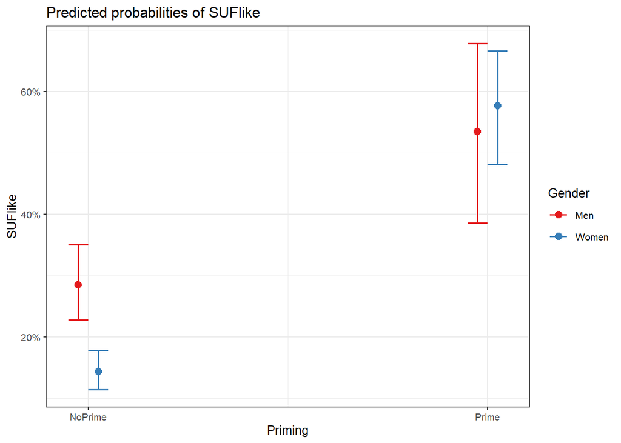

```r
plot_model(m6.glmer, type = "pred", terms = c("Priming", "Gender"))
```

### Extracting Model Fit Parameters

We now extract model fit parameters (Baayen 2008, 281).

```r
probs = 1/(1+exp(-fitted(mlr.glmer)))
probs = binomial()$linkinv(fitted(mlr.glmer))
# convert SUFlike to binary
mblrdata$SUFlike <- ifelse(mblrdata$SUFlike == "1", 1, 0)
Hmisc::somers2(probs, mblrdata$SUFlike, normwt = T)
```

```
##         C       Dxy         n   Missing
##    0.7583    0.5167 2000.0000    0.0000
```

The two lines that start with `probs` are simply two different ways to do the same thing (you only need one of these).

The model fit parameters indicate a suboptimal fit. Both the C-value and Somers’s D<sub>xy</sub> show poor fit between predicted and observed occurrences of discourse *like*. If the C-value is 0.5, the predictions are random, while the predictions are perfect if the C-value is 1. C-values above 0.8 indicate real predictive capacity (Baayen 2008, 204). Somers’ D<sub>xy</sub> is a value that represents a rank correlation between predicted probabilities and observed responses. Somers’ D<sub>xy</sub> values range between 0, which indicates complete randomness, and 1, which indicates perfect prediction (Baayen 2008, 204). The C-value of 0.7583 suggests that the model has some predictive and explanatory power, but not at an optimal level. We now check the prediction accuracy.

In order to calculate the prediction accuracy of the model, we generate a variable called *Prediction* that contains the predictions of pour model and which we add to the data. Then, we use the `confusionMatrix` function from the `caret` package to extract the prediction accuracy.

```r
# create variable with contains the prediction of the model
mblrdata <- mblrdata %>%
  dplyr::mutate(Prediction = predict(mlr.glmer, type = "response"),
                Prediction = ifelse(Prediction > .5, 1, 0),
                Prediction = factor(Prediction, levels = c("0", "1")),
                SUFlike = factor(SUFlike, levels = c("0", "1")))
# create a confusion matrix with compares observed against predicted values
caret::confusionMatrix(mblrdata$Prediction, mblrdata$SUFlike)
```

```
## Confusion Matrix and Statistics
##
##           Reference
## Prediction    0    1
##          0 1620  299
##          1   36   45
##
##                Accuracy : 0.833
##                  95% CI : (0.815, 0.849)
##     No Information Rate : 0.828
##     P-Value [Acc > NIR] : 0.309
##
##                   Kappa : 0.156
##
##  Mcnemar's Test P-Value : <0.0000000000000002
##
##             Sensitivity : 0.978
##             Specificity : 0.131
##          Pos Pred Value : 0.844
##          Neg Pred Value : 0.556
##              Prevalence : 0.828
##          Detection Rate : 0.810
##    Detection Prevalence : 0.960
##       Balanced Accuracy : 0.555
##
##        'Positive' Class : 0
##
```

### Model Summary

As a final step, we summarize our findings in tabulated form.

```r
# summarize final model
sjPlot::tab_model(mlr.glmer)
```

|  | SUFlike |  |  |
| --- | --- | --- | --- |
| Predictors | Odds Ratios | CI | p |
| (Intercept) | 0.40 | 0.29 – 0.54 | **<0.001** |
| Priming [Prime] | 2.89 | 1.50 – 5.56 | **0.002** |
| Gender [Women] | 0.42 | 0.29 – 0.61 | **<0.001** |
| ConversationType [SameGender] | 0.61 | 0.46 – 0.82 | **0.001** |
| Priming [Prime] * Gender [Women] | 2.82 | 1.34 – 5.93 | **0.006** |
| Random Effects |  |  |  |
| σ<sup>2</sup> | 3.29 |  |  |
| τ<sub>00</sub> <sub>ID</sub> | 0.09 |  |  |
| ICC | 0.03 |  |  |
| N <sub>ID</sub> | 208 |  |  |
| Observations | 2000 |  |  |
| Marginal R<sup>2</sup> / Conditional R<sup>2</sup> | 0.138 / 0.160 |  |  |

A mixed-effect binomial logistic regression model with random intercepts for speakers was fit to the data in a step-wise-step up procedure. The final minimal adequate model performed significantly better than an intercept-only base line model ($\chi$<sup>2</sup>(4): 173.3278, p = 0) and a good but not optimal fit (C: 0.7583, Somers’ D<sub>xy</sub>: 0.5167). The final minimal adequate model reported that speakers use more discourse *like* in mixed-gender conversations compared to same-gender conversations ($\chi$<sup>2</sup>(1): 12.8138, p = 0.0003) and that there is an interaction between priming and gender with men using more discourse *like* in un-primed contexts while this gender difference is not present in primed contexts where speakers more more likely to use discourse *like* regardless of gender ($\chi$<sup>2</sup>(1): 7.4187, p = 0.0064).

# Citation & Session Info

Schweinberger, Martin. 2021. *Mixed-Effect Modeling in R*. Tromsø: The Artic University of Norway. url: https://slcladal.github.io/mmws.html (Version 2021.04.29).

```
@manual{schweinberger2021mmws,
  author = {Schweinberger, Martin},
  title = {Fixed- and Mixed-Effects Regression Models in R},
  note = {https://slcladal.github.io/mmws.html},
  year = {2021},
  organization = "Arctic University of Norway, AcqVA Aurora Center},
  address = {Tromsø},
  edition = {2021.04.29}
}
```

Back to top

# References

Achen, Christopher H. 1982. *Interpreting and Using Regression*. Vol. 29. Sage.

Austin, Peter C., and George Leckie. 2018. “The Effect of Number of Clusters and Cluster Size on Statistical Power and Type I Error Rates When Testing Random Effects Variance Components in Multilevel Linear and Logistic Regression Models.” *Journal of Statistical Computation and Simulation* 88 (16): 3151–63.

Baayen, R Harald. 2008. *Analyzing Linguistic Data. A Practical Introduction to Statistics Using R*. Cambridge: Cambridge University press.

Bartoń, Kamil. 2020. “Package Mumin - Multi-Model Inference.” The Comprehensive R Archive Network. https://cran.r-project.org/web/packages/MuMIn/MuMIn.pdf.

Bell, Bethany A., John M. Ferron, and Jeffrey D. Kromrey. 2008. “Cluster Size in Multilevel Models: The Impact of Sparse Data Structures on Point and Interval Estimates in Two-Level Models.” In *JSM Proceedings. Section on Survey Research Methods*, 1122–9. American Statistical Association Alexandria, VA.

Booth GD, Schuster EG, Niccolucci MJ. 1994. “Identifying Proxy Sets in Multiple Linear Regression: An Aid to Better Coefficient Interpretation. Research Paper Int-470.”

Bortz, Jürgen. 2006. *Statistik: Für Human-Und Sozialwissenschaftler*. Springer-Verlag.

Bowerman, Bruce L, and Richard T O’Connell. 1990. *Linear Statistical Models: An Applied Approach*. Boston: PWS-Kent.

Clarke, Philippa. 2008. “When Can Group Level Clustering Be Ignored? Multilevel Models Versus Single-Level Models with Sparse Data.” *Journal of Epidemiology & Community Health* 62 (8): 752–58.

Clarke, Philippa, and Blair Wheaton. 2007. “Addressing Data Sparseness in Contextual Population Research: Using Cluster Analysis to Create Synthetic Neighborhoods.” *Sociological Methods & Research* 35 (3): 311–51.

Crawley, Michael J. 2005. *Statistics: An Introduction Using R. 2005*. Chichester, West Sussex: John Wiley & Sons.

———. 2012. *The R Book*. John Wiley & Sons.

Faraway, Julian J. 2002. *Practical Regression and Anova Using R.* University of Bath.

Field, Andy, Jeremy Miles, and Zoe Field. 2012. *Discovering Statistics Using R*. Sage.

Gries, Stefan Th. 2021. *Statistics for Linguistics Using R: A Practical Introduction*. Berlin & New York: Mouton de Gruyter.

Johnson, Daniel Ezra. 2009. “Getting Off the Goldvarb Standard: Introducing Rbrul for Mixed-Effects Variable Rule Analysis.” *Language and Linguistics Compass* 3 (1): 359–83.

Levshina, Natalia. 2015. *How to Do Linguistics with R: Data Exploration and Statistical Analysis*. Amsterdam: John Benjamins Publishing Company.

Maas, Cora JM, and Joop J Hox. 2005. “Sufficient Sample Sizes for Multilevel Modeling.” *Methodology* 1 (3): 86–92.

Myers, Raymond H. 1990. *Classical and Modern Regression with Applications*. Vol. 2. Duxbury Press Belmont, CA.

Neter, J., W. Wasserman, and MH Kutner. 1990. *Applied Linear Statistical Models. Regression, Analysis of Variance, and Experimental Design*. Irwin, Homewood, USA.

Pinheiro, J. C., and D. M. Bates. 2000. *Mixed-Effects Models in S and S-Plus. Statistics and Computing*. New York: Springer.

Szmrecsanyi, Benedikt. 2006. *Morphosyntactic Persistence in Spoken English: A Corpus Study at the Intersection of Variationist Sociolinguistics, Psycholinguistics, and Discourse Analysis*. Berlin & New York: Walter de Gruyter.

Wilcox, Rand R. 2009. *Basic Statistics: Understanding Conventional Methods and Modern Insights*. Oxford University Press.

Winter, Bodo. 2019. *Statistics for Linguists: An Introduction Using R*. Routledge.

Zuur, Alain F., Joseph M. Hilbe, and Elena N. Ieno. 2013. *A Beginner’s Guide to Glm and Glmm with. R. Beginner’s Guide Series*. Newburgh, United Kingdom: Highland Statistics Ltd.

Zuur, Alain F., Elena N. Ieno, and Chris S. Elphick. 2010. “A Protocol for Data Exploration to Avoid Common Statistical Problems.” *Methods in Ecology and Evolution* 1 (1): 3–14.

Zuur, Alain F., Elena N. Ieno, Neil J. Walker, Anatoly A. Saveliev, and Graham M Smith. 2009. *Mixed Effects Models and Extensions in Ecology with R*. Springer.